# Architectural uniformity and spatial variation in Tairona residential terraces of the Río Frío basin, Colombia

Geospatial data sets associated with the Regional Archaeology Program of the Río Frío Basin

Syntax written by [Luis Miguel Soto Rodríguez](https://sites.google.com/view/arch-data-1/home-page) , Ph.D. student at the University of Pittsburgh on November 25, 2026

## Data access and reproducibility

The terrace inventory and the survey polygon are loaded directly from the `Rdata` folder of the [GitHub repository](https://github.com/luismiguelsoto/Architectural_uniformity_and_spatial_variation_in_Tairona_residential_terraces_of_the_Rio_Frio_basin/tree/main/Rdata). The default Git reference is `main`; set `RIOFRIO_GITHUB_REF` to a commit SHA to reproduce a fixed repository version. Public repositories require no credentials. For private access, set `GITHUB_PAT` in your personal `.Renviron` file (or provide `GH_TOKEN` or `GITHUB_TOKEN` in the environment) using a token with read access to repository contents, then restart R. Never include a token in this notebook or commit it to the repository.

The original terrain analyses require the same `FINAL_DEM_GENERAL_ALOS_PALSAR.tif` used in V7. This raster is not one of the two RData files shown in the repository. The notebook retains the original local DEM search paths; alternatively, set `RIOFRIO_DEM_FILE` to the full path of that raster. Terrain analyses remain enabled by default. The notebook stops if the required raster is unavailable rather than silently dropping terrain analyses or substituting a different elevation model.

```r
# 01. Settings and analysis parameters
options(stringsAsFactors = FALSE, scipen = 999, width = 88)
SEED <- 20261110L
set.seed(SEED)
RUN_STARTED_AT <- Sys.time()
FIG_WIDTH_MM <- 174
FIG_HEIGHT_MM <- c(FIGURE_3 = 110, FIGURE_4 = 210, FIGURE_5 = 215,
                   FIGURE_6 = 225, FIGURE_7 = 215, FIGURE_8 = 185)
knitr::opts_chunk$set(echo = TRUE, warning = TRUE, message = FALSE, comment = "##",
                      fig.width = FIG_WIDTH_MM / 25.4, fig.height = 3.2, out.width = "100%",
                      fig.align = "center", dpi = 300)
env_true <- function(key, default = "FALSE") identical(toupper(Sys.getenv(key, default)), "TRUE")
QUICK_TEST <- env_true("RIOFRIO_QUICK_TEST")
q_or <- function(full, quick) if (isTRUE(QUICK_TEST)) quick else full
GITHUB_OWNER <- "luismiguelsoto"
GITHUB_REPO <- paste0("Architectural_uniformity_and_spatial_variation_in_",
                      "Tairona_residential_terraces_of_the_Rio_Frio_basin")
GITHUB_REF <- Sys.getenv("RIOFRIO_GITHUB_REF", "main")
GITHUB_FOLDER <- "Rdata"
TERRACES_FILE <- "AAS_TERRACES.RData"
POLYGON_FILE <- "AAS_POLYGON_SURVEY_RIO_FRIO.RData"
# Local search paths apply only to the original DEM, not the vector data.
DATA_DIR_PREFERRED <- paste0("C:/Users/USER/OneDrive - University of Pittsburgh/",
                             "ARTICULOS INGLES SIERRA NEVADA DE SANTA MARTA/",
                             "Anthropological and Archaeological Sciences/GITHUB")
DATA_DIR_OVERRIDE <- Sys.getenv("RIOFRIO_DATA_DIR", "")
EXTRA_DATA_DIR <- "C:/Users/USER/Documents/INSUMOS_GIS/DIAGNOSTICOS"
DEM_FILE <- Sys.getenv("RIOFRIO_DEM_FILE", "FINAL_DEM_GENERAL_ALOS_PALSAR.tif")
USE_DEM_MARKS <- env_true("RIOFRIO_DEM_MARKS", "TRUE")
USE_DEM_INTENSITY <- env_true("RIOFRIO_DEM_INTENSITY", "FALSE")
USE_DEM <- USE_DEM_MARKS || USE_DEM_INTENSITY
RUN_CALIBRATION <- env_true("RIOFRIO_CALIBRATE", "TRUE")
EXPECTED_TERRACES <- 2526L
EXPECTED_AREA_KM2 <- 52.1988
EXPECTED_CRS <- 32618L
ID_FIELD <- "Terr_ID"
DIAMETER_FIELD <- "Diam_Terra"
EAST_FIELD <- "UTM_East"
NORTH_FIELD <- "UTM_North"
COORD_TOL_M <- 0.01
N_SIM <- q_or(10000L, 39L)
N_PERM <- q_or(10000L, 39L)
N_BOOT <- q_or(10000L, 39L)
N_SENS <- q_or(1000L, 39L)
N_MODEL <- q_or(999L, 39L)
N_CAL_OUTER <- q_or(199L, 19L)
N_CAL_INNER <- q_or(99L, 19L)
ALPHA <- 0.05
CV_FOLDS <- 5L
CV_BLOCKS <- 25L
CV_REPEATS <- q_or(10L, 3L)
CV_BUFFER_M <- 250
EDGE_BUFFER_M <- 250
LOO_REGIONS <- 5L
CONCENTRATION_RADII_M <- c(50, 100, 200, 500, 1000)
PRIMARY_RADIUS_M <- 100
LAG_RADIUS_M <- 50
MARK_BREAKS_M <- c(0, 25, 50, 100, 200, 350, 500, 750, 1000, 1500, 2000)
MARK_BREAKS_ALT_M <- c(0, 50, 150, 300, 600, 1000, 1500, 2000)
MIN_PAIRS_PER_BAND <- 50L
MIN_TERRACES_PER_BAND <- 10L
NEAR_MAX_M <- 50
MIN_LOCAL_NEIGHBORS <- 3L
FIXED_DOMAIN_M <- c(100, 500)
DISPLAY_MAX_M <- max(MARK_BREAKS_M)
PCF_R_M <- seq(0, 1000, by = 20)
PCF_FINE_R_M <- seq(0, 100, by = 5)
PCF_SIGMA_M <- 500
PCF_BW_M <- 20
DEM_RES_M <- 30
DEM_SCALE_M <- 150
BOOT_BLOCK_M <- 500
CLOSE_LIMIT_M <- 2
TYPICAL_DIAMETER_M <- c(8, 13)
RUN_PARALLEL <- TRUE
REPORT_WIDTH <- 88L
RUN_VARIANT <- paste0(if (USE_DEM_MARKS) "terrain_marks" else "no_terrain_marks",
                      if (USE_DEM_INTENSITY) "_terrain_intensity" else "_coordinate_intensity")
FIG_DIR <- getwd()
SAVED_FIGURES <- character()
```

```r
# 02. Required packages and thread settings
req <- c("sf", "ggplot2", "patchwork", "scales", "knitr", "spatstat.geom", "spatstat.explore",
         "spatstat.random", "spatstat.model", "GET", "curl")
if (USE_DEM) req <- c(req, "terra")
missing_packages <- req[!vapply(req, requireNamespace, logical(1), quietly = TRUE)]
if (length(missing_packages)) {
  stop("Missing CRAN packages: ", paste(missing_packages, collapse = ", "),
       ". This notebook never installs packages.")
}
if (!requireNamespace("ggspatial", quietly = TRUE)) {
  stop("Missing CRAN package for the maps: ggspatial. This notebook never installs packages.")
}
if (utils::packageVersion("spatstat.explore") < "3.8-2") {
  stop("spatstat.explore 3.8-2 or later is required.")
}
if (utils::packageVersion("ggplot2") < "3.5.0") stop("ggplot2 3.5.0 or later is required.")
suppressPackageStartupMessages({
  library(sf); library(ggplot2); library(patchwork)
})
Sys.setenv(OMP_NUM_THREADS = "1", OPENBLAS_NUM_THREADS = "1", MKL_NUM_THREADS = "1",
           BLIS_NUM_THREADS = "1", VECLIB_MAXIMUM_THREADS = "1")
if (requireNamespace("RhpcBLASctl", quietly = TRUE)) {
  RhpcBLASctl::blas_set_num_threads(1L)
  RhpcBLASctl::omp_set_num_threads(1L)
}
```

```r
# 03. Reporting and plotting helpers
fmt_num <- function(x, digits = 4L) {
  x <- suppressWarnings(as.numeric(x))
  out <- rep("NA", length(x))
  ok <- is.finite(x)
  int_like <- ok & abs(x - round(x)) < 1e-9 & abs(x) < 1e12
  out[int_like] <- sprintf("%.0f", round(x[int_like]))
  dec <- ok & !int_like
  out[dec] <- trimws(formatC(x[dec], digits = digits, format = "g"))
  inf <- !ok & !is.na(x)
  out[inf] <- as.character(x[inf])
  out
}
fmt_p <- function(p) {
  p <- suppressWarnings(as.numeric(p))
  ifelse(is.finite(p), trimws(formatC(p, digits = 2, format = "fg")), "NA")
}
fmt_value <- function(v, digits = 4L) {
  if (is.factor(v)) v <- as.character(v)
  if (is.logical(v)) return(ifelse(is.na(v), "NA", ifelse(v, "TRUE", "FALSE")))
  if (is.numeric(v)) return(fmt_num(v, digits))
  v <- as.character(v)
  v[is.na(v)] <- "NA"
  gsub(";", ",", v, fixed = TRUE)
}
interval_text <- function(lo, hi, digits = 4L) paste(fmt_num(lo, digits), "to", fmt_num(hi, digits))
vector_text <- function(x, digits = 4L) paste(fmt_value(x, digits), collapse = ", ")
hard_split <- function(s, width) {
  n <- nchar(s, type = "chars")
  if (n <= width) return(s)
  starts <- seq(1L, n, by = width)
  substring(s, starts, pmin(starts + width - 1L, n))
}
split_long <- function(s, width, indent) {
  if (nchar(s, type = "width") <= width) return(s)
  lead <- nchar(s) - nchar(sub("^ +", "", s))
  w <- strwrap(s, width = width, indent = lead, exdent = max(lead, indent))
  unlist(lapply(w, hard_split, width = width), use.names = FALSE)
}
pack_fields <- function(f, width = REPORT_WIDTH, indent = 4L) {
  out <- character(); cur <- ""
  for (x in f) {
    trial <- if (nzchar(cur)) paste0(cur, "; ", x) else x
    if (nchar(trial, type = "width") <= width) { cur <- trial; next }
    if (nzchar(cur)) out <- c(out, cur)
    cur <- paste0(if (length(out)) strrep(" ", indent) else "", x)
  }
  if (nzchar(cur)) out <- c(out, cur)
  unlist(lapply(out, split_long, width = width, indent = indent), use.names = FALSE)
}
emit_rows <- function(...) {
  x <- list(...)
  n <- max(vapply(x, length, integer(1)))
  for (i in seq_len(n)) {
    f <- vapply(seq_along(x), function(j) {
      v <- x[[j]]
      paste0(names(x)[j], "=", fmt_value(v[if (length(v) == 1L) 1L else i]))
    }, character(1))
    writeLines(pack_fields(f))
  }
  invisible(NULL)
}
emit_text <- function(key, text) {
  for (s in text) writeLines(pack_fields(paste0(key, "=", gsub(";", ",", s, fixed = TRUE))))
  invisible(NULL)
}
report_start <- function(id, shows, encoding) {
  writeLines(pack_fields(c(paste0("REPORT=", id), paste0("SHOWS=", shows))))
  emit_text("ENCODING", encoding)
}
heading <- function(text, level = 1L) {
  cat("\n\n", strrep("#", level), " ", text, "\n\n", sep = "")
}
check_caption <- function(s) { stopifnot(nchar(s, type = "chars") < 400L); s }
print_caption <- function(kind, number, caption) {
  caption <- sub("[.][[:space:]]*$", "", check_caption(caption))
  label <- if (kind == "Figure") "Fig." else kind
  cat("\n\n**", label, " ", number, "** ", caption, "\n\n", sep = "")
}
latex_escape <- function(x) {
  x <- as.character(x)
  x <- gsub("([&%$#_{}])", "\\\\\\1", x)
  x <- gsub("~", "\\textasciitilde{}", x, fixed = TRUE)
  x <- gsub("^", "\\textasciicircum{}", x, fixed = TRUE)
  x
}
latex_table <- function(df, total = 0.92, chars_per_line = 90) {
  m <- as.matrix(df); storage.mode(m) <- "character"; m[is.na(m)] <- "NA"
  cells <- rbind(names(df), m)
  words <- apply(cells, 2, function(col)
    max(nchar(unlist(strsplit(col, "[[:space:]]+"))), 1L))
  avg <- apply(cells, 2, function(col) mean(nchar(col)))
  base <- words + 1
  spare <- max(0, chars_per_line - sum(base))
  extra <- pmax(avg - base, 0)
  w <- base + if (sum(extra) > 0) spare * extra / sum(extra) else spare / length(base)
  w <- w / sum(w) * total
  spec <- paste0("@{}", paste0(">{\\raggedright\\arraybackslash}p{", sprintf("%.3f", w),
                               "\\linewidth}", collapse = ""), "@{}")
  body <- matrix(latex_escape(m), nrow = nrow(m))
  rows <- apply(body, 1, function(r) paste0(paste(r, collapse = " & "), " \\\\"))
  c("\\begingroup\\small", "\\setlength{\\tabcolsep}{3pt}",
    paste0("\\begin{longtable}{", spec, "}"), "\\toprule",
    paste0(paste(latex_escape(names(df)), collapse = " & "), " \\\\"), "\\midrule",
    "\\endhead", "\\bottomrule", "\\endlastfoot", rows, "\\end{longtable}", "\\endgroup")
}
print_table <- function(df) {
  if (isTRUE(knitr::is_latex_output())) {
    cat("\n", paste(latex_table(df), collapse = "\n"), "\n\n", sep = "")
  } else {
    cat("\n\n"); print(knitr::kable(df, format = "pipe")); cat("\n\n")
  }
}
qv <- function(x, p = c(.025, .5, .975)) as.numeric(stats::quantile(x, p, names = FALSE))
mc_p <- function(obs, sim) {
  min(1, 2 * min((1 + sum(sim <= obs)) / (length(sim) + 1),
                 (1 + sum(sim >= obs)) / (length(sim) + 1)))
}
tint <- function(col, f = 0.7) {
  m <- grDevices::col2rgb(col) / 255
  grDevices::rgb(t(m + (1 - m) * f))
}
COL <- c(observed = "#440154", reference = "#3B528B", global = "#21908C", regional = "#5DC863",
         outside = "#F89540", fit = "#D7191C", neutral = "black")
theme_v7 <- function() {
  theme_bw(base_size = 9) +
    theme(text = element_text(colour = "black"),
          line = element_line(colour = "black"),
          rect = element_rect(colour = "black"),
          legend.position = "bottom", legend.box = "vertical", legend.title.position = "top",
          legend.margin = margin(0, 0, 0, 0), legend.key.size = grid::unit(3.5, "mm"),
          legend.text = element_text(size = 7.5, colour = "black"),
          legend.title = element_text(size = 7.5, colour = "black"),
          panel.grid = element_blank(),
          panel.grid.minor = element_blank(),
          panel.grid.major = element_blank(),
          panel.border = element_rect(fill = NA, colour = "black"),
          strip.background = element_rect(fill = "white", colour = "black"),
          strip.text = element_text(face = "bold", size = 7.5, colour = "black"),
          axis.text = element_text(size = 7, colour = "black"),
          axis.title = element_text(size = 8.5, colour = "black"),
          axis.ticks = element_line(colour = "black"),
          plot.title = element_text(colour = "black"),
          plot.subtitle = element_text(colour = "black"),
          plot.caption = element_text(colour = "black"),
          plot.tag = element_text(face = "bold", size = 10, colour = "black"),
          plot.margin = margin(3, 5, 3, 3))
}
save_figure <- function(plot, name, height_mm) {
  stopifnot(height_mm <= 234, name %in% names(FIG_HEIGHT_MM))
  file <- file.path(FIG_DIR, paste0(name, ".pdf"))
  ggplot2::ggsave(file, plot, width = FIG_WIDTH_MM, height = height_mm, units = "mm",
                  device = grDevices::pdf, bg = "white", useDingbats = FALSE)
  file
}
band_text <- function(meta) paste0(fmt_num(meta$Lower_m), "-", fmt_num(meta$Upper_m))
bands_outside <- function(bt, flag) if (any(flag)) paste(bt[flag], collapse = ", ") else "none"
outside_runs <- function(x, flag) {
  flag <- as.logical(flag)
  if (!any(flag)) return("none")
  r <- rle(flag)
  ends <- cumsum(r$lengths)
  starts <- ends - r$lengths + 1L
  s <- starts[r$values]
  e <- ends[r$values]
  paste(ifelse(s == e, fmt_num(x[s]), paste0(fmt_num(x[s]), "-", fmt_num(x[e]))),
        collapse = ",")
}
value_at <- function(df, at, col = "Observed") {
  vapply(at, function(z) df[[col]][which.min(abs(df$Distance_m - z))], numeric(1))
}
envelope_at <- function(df, at) {
  k <- which.min(abs(df$Distance_m - at))
  interval_text(df$Low[k], df$High[k], 3)
}
```

```r
# 04. Parallel computation and internal cache
if (exists("CLUSTER", inherits = FALSE) && inherits(CLUSTER, "cluster")) {
  try(parallel::stopCluster(CLUSTER), silent = TRUE)
}
CLUSTER <- NULL
logical_processors <- suppressWarnings(as.integer(parallel::detectCores(logical = TRUE)))
if (!is.finite(logical_processors) || logical_processors < 1L) logical_processors <- 2L
physical_processors <- suppressWarnings(as.integer(parallel::detectCores(logical = FALSE)))
if (!is.finite(physical_processors) || physical_processors < 1L) {
  physical_processors <- logical_processors
}
requested_workers <- suppressWarnings(as.integer(Sys.getenv("RIOFRIO_WORKERS", "")))
CPU_WORKERS <- if (!isTRUE(RUN_PARALLEL)) {
  1L
} else if (is.finite(requested_workers) && requested_workers >= 1L) {
  min(requested_workers, logical_processors)
} else {
  max(1L, logical_processors - 2L)
}
if (QUICK_TEST) CPU_WORKERS <- min(CPU_WORKERS, 2L)
PARALLEL_BLOCKS <- CPU_WORKERS
USE_CACHE <- env_true("RIOFRIO_CACHE", "TRUE")
CACHE_DIR <- Sys.getenv("RIOFRIO_CACHE_DIR", tools::R_user_dir("riofrio_terraces", "cache"))
if (USE_CACHE) dir.create(CACHE_DIR, showWarnings = FALSE, recursive = TRUE)
CACHE_FINGERPRINT <- c(R.version.string, "per-realization seeds",
                       vapply(req, function(p) paste(p, as.character(utils::packageVersion(p))),
                              character(1)))
MC_LOG <- data.frame(Label = character(), B = integer(), Cached = logical(),
                     Seconds = numeric())
hash_object <- function(x) {
  f <- tempfile(fileext = ".bin")
  on.exit(unlink(f), add = TRUE)
  writeBin(serialize(x, NULL, version = 3L), f)
  unname(tools::md5sum(f))
}
mc_worker <- function(ids, callback, p, seed0) {
  values <- lapply(ids, function(k) {
    set.seed(seed0 + k)
    z <- callback(k, p)
    if (!is.numeric(z) || any(!is.finite(z))) stop("Invalid realization ", k)
    as.numeric(z)
  })
  list(ids = ids, values = do.call(rbind, values))
}
environment(mc_worker) <- baseenv()
cache_file <- function(B, step, payload, seed, label) {
  is_fun <- vapply(payload, is.function, logical(1))
  code <- c(deparse(mc_worker), deparse(step),
            unlist(lapply(payload[is_fun], deparse), use.names = FALSE))
  key <- hash_object(list(label, as.integer(seed), as.integer(B), CACHE_FINGERPRINT, code,
                          names(payload), payload[!is_fun]))
  file.path(CACHE_DIR, paste0(gsub("[^A-Za-z0-9]+", "_", label), "_", key, ".rds"))
}
get_cluster <- function() {
  if (CPU_WORKERS < 2L) return(NULL)
  alive <- !is.null(CLUSTER) &&
    isTRUE(tryCatch(all(unlist(parallel::clusterCall(CLUSTER, function() TRUE))),
                    error = function(e) FALSE))
  if (!alive) {
    CLUSTER <<- tryCatch(parallel::makeCluster(CPU_WORKERS, type = "PSOCK"),
                         error = function(e) {
                           warning("PSOCK unavailable: ", conditionMessage(e))
                           NULL
                         })
    if (!is.null(CLUSTER)) {
      parallel::clusterCall(CLUSTER, function() {
        Sys.setenv(OMP_NUM_THREADS = "1", OPENBLAS_NUM_THREADS = "1", MKL_NUM_THREADS = "1",
                   BLIS_NUM_THREADS = "1")
        if (requireNamespace("RhpcBLASctl", quietly = TRUE)) {
          RhpcBLASctl::blas_set_num_threads(1L)
          RhpcBLASctl::omp_set_num_threads(1L)
        }
        NULL
      })
    }
  }
  CLUSTER
}
mc_run <- function(B, step, payload, seed, label) {
  stopifnot(B >= 1L, seed + B < .Machine$integer.max)
  environment(step) <- baseenv()
  started <- Sys.time()
  file <- if (USE_CACHE) cache_file(B, step, payload, seed, label) else NA_character_
  m <- NULL
  if (USE_CACHE && file.exists(file)) {
    m <- tryCatch(readRDS(file), error = function(e) NULL)
    if (!is.matrix(m) || nrow(m) != B || !all(is.finite(m))) m <- NULL
  }
  cached <- !is.null(m)
  if (!cached) {
    tasks <- split(seq_len(B), rep(seq_len(min(B, PARALLEL_BLOCKS)), length.out = B))
    cl <- if (length(tasks) > 1L) get_cluster() else NULL
    out <- if (is.null(cl)) {
      lapply(tasks, mc_worker, callback = step, p = payload, seed0 = seed)
    } else {
      parallel::parLapply(cl, tasks, mc_worker, callback = step, p = payload, seed0 = seed)
    }
    ids <- unlist(lapply(out, `[[`, "ids"), use.names = FALSE)
    m <- do.call(rbind, lapply(out, `[[`, "values"))[order(ids), , drop = FALSE]
    stopifnot(identical(sort(ids), seq_len(B)), nrow(m) == B, all(is.finite(m)))
    if (USE_CACHE) saveRDS(m, file)
  }
  MC_LOG <<- rbind(MC_LOG, data.frame(Label = label, B = B, Cached = cached,
                                      Seconds = round(as.numeric(difftime(Sys.time(), started,
                                                                          units = "secs")), 1)))
  m
}
emit_rows(PARALLEL = if (CPU_WORKERS > 1L) "PSOCK, persistent" else "serial",
          LOGICAL_PROCESSORS = logical_processors, PHYSICAL_PROCESSORS = physical_processors,
          WORKERS = CPU_WORKERS, QUICK_TEST = QUICK_TEST, RESULTS_FOR_INFERENCE = !QUICK_TEST)
```

```
## PARALLEL=PSOCK, persistent; LOGICAL_PROCESSORS=32; PHYSICAL_PROCESSORS=16; WORKERS=30
##     QUICK_TEST=FALSE; RESULTS_FOR_INFERENCE=TRUE
```

```r
emit_rows(TERRAIN_MARKS = USE_DEM_MARKS, TERRAIN_INTENSITY = USE_DEM_INTENSITY,
          CALIBRATION = RUN_CALIBRATION, N_PRIMARY = N_PERM, N_SENSITIVITY = N_SENS)
```

```
## TERRAIN_MARKS=TRUE; TERRAIN_INTENSITY=FALSE; CALIBRATION=TRUE; N_PRIMARY=10000
##     N_SENSITIVITY=1000
```

```r
emit_rows(CACHE = USE_CACHE, CACHE_DIR = CACHE_DIR)
```

```
## CACHE=TRUE; CACHE_DIR=C:\Users\USER\AppData\Local/R/cache/R/riofrio_terraces
```

```r
emit_text("R_VERSION", R.version.string)
```

```
## R_VERSION=R version 4.6.1 (2026-06-24 ucrt)
```

# 1. Data, observation window and terrain context

```r
# 06. Download GitHub RData files and validate spatial inputs
# Keep the original local resolver exclusively for the DEM.
search_dirs <- unique(Filter(nzchar, c(DATA_DIR_OVERRIDE, DATA_DIR_PREFERRED, getwd(),
                                       EXTRA_DATA_DIR)))
resolve_input <- function(file) {
  candidates <- if (grepl("^([A-Za-z]:|/)", file)) file else file.path(search_dirs, file)
  found <- candidates[file.exists(candidates)]
  if (!length(found)) {
    stop("DEM not found: ", file, ". Searched: ", paste(search_dirs, collapse = " | "),
         ". Set RIOFRIO_DEM_FILE to the original raster's full path.")
  }
  normalizePath(found[1], winslash = "/", mustWork = TRUE)
}
GITHUB_INPUT_DIR <- tempfile("aas_rio_frio_github_")
if (!dir.create(GITHUB_INPUT_DIR, recursive = TRUE)) {
  stop("Unable to create a temporary directory for GitHub inputs")
}

download_github_rdata <- function(file) {
  stopifnot(nzchar(GITHUB_REF), basename(file) == file)
  # Read credentials from the environment only; never print or save them.
  tokens <- Sys.getenv(c("GITHUB_PAT", "GH_TOKEN", "GITHUB_TOKEN"), unset = "")
  tokens <- unname(tokens[nzchar(tokens)])
  token <- if (length(tokens)) tokens[1] else ""
  ref <- utils::URLencode(GITHUB_REF, reserved = TRUE)
  remote_path <- paste(GITHUB_FOLDER, file, sep = "/")
  handle <- curl::new_handle(connecttimeout = 30L, timeout = 300L,
                              followlocation = TRUE)
  if (nzchar(token)) {
    # GitHub Contents API returns the binary file with this media type.
    remote_url <- paste0("https://api.github.com/repos/", GITHUB_OWNER, "/",
                         GITHUB_REPO, "/contents/", remote_path, "?ref=", ref)
    curl::handle_setheaders(handle, Authorization = paste("Bearer", token),
                            Accept = "application/vnd.github.raw+json",
                            `X-GitHub-Api-Version` = "2022-11-28",
                            `User-Agent` = "AAS-RIO-FRIO-2026")
  } else {
    remote_url <- paste0("https://raw.githubusercontent.com/", GITHUB_OWNER, "/",
                         GITHUB_REPO, "/", ref, "/", remote_path)
  }
  dest <- file.path(GITHUB_INPUT_DIR, file)
  response <- tryCatch(curl::curl_fetch_disk(remote_url, dest, handle = handle),
                       error = function(e) {
                         unlink(dest)
                         stop("GitHub download failed for ", file, ": ",
                              conditionMessage(e), call. = FALSE)
                       })
  if (response$status_code != 200L || !file.exists(dest) ||
      !isTRUE(file.info(dest)$size > 0)) {
    unlink(dest)
    stop("GitHub download failed for ", file, " (HTTP ", response$status_code,
         "). Check the repository, reference, path, and read permissions. ",
         "For a private repository, configure GITHUB_PAT and restart R.", call. = FALSE)
  }
  normalizePath(dest, winslash = "/", mustWork = TRUE)
}

read_sf_rdata <- function(path) {
  # Isolate serialized objects from the notebook's analysis environment.
  e <- new.env(parent = emptyenv())
  object_names <- tryCatch(load(path, envir = e), error = function(err) {
    stop("Invalid RData file ", basename(path), ": ", conditionMessage(err),
         call. = FALSE)
  })
  sf_names <- object_names[vapply(object_names, function(nm) {
    inherits(get(nm, envir = e, inherits = FALSE), "sf")
  }, logical(1))]
  if (length(sf_names) != 1L) {
    stop("Expected exactly one sf object in ", basename(path), "; found ",
         length(sf_names), ". Objects: ", paste(object_names, collapse = ", "),
         call. = FALSE)
  }
  get(sf_names[1], envir = e, inherits = FALSE)
}

terrace_path <- download_github_rdata(TERRACES_FILE)
polygon_path <- download_github_rdata(POLYGON_FILE)
architecture <- read_sf_rdata(terrace_path)
survey <- read_sf_rdata(polygon_path)
for (obj in list(architecture, survey)) {
  if (!identical(as.integer(sf::st_crs(obj)$epsg), EXPECTED_CRS)) {
    stop("Inputs must use EPSG:32618")
  }
  if (any(sf::st_is_empty(obj)) || !all(sf::st_is_valid(obj) %in% TRUE)) {
    stop("Invalid or empty input geometry")
  }
}
architecture <- sf::st_zm(architecture, drop = TRUE, what = "ZM")
survey <- sf::st_zm(survey, drop = TRUE, what = "ZM")
stopifnot(all(as.character(sf::st_geometry_type(architecture)) == "POINT"),
          all(as.character(sf::st_geometry_type(survey)) %in% c("POLYGON", "MULTIPOLYGON")))
needed_fields <- c(ID_FIELD, DIAMETER_FIELD, EAST_FIELD, NORTH_FIELD)
if (length(setdiff(needed_fields, names(architecture)))) {
  stop("Missing fields: ", paste(setdiff(needed_fields, names(architecture)), collapse = ", "))
}
survey_union <- sf::st_union(sf::st_geometry(survey))
inside <- lengths(sf::st_covered_by(architecture, survey_union)) > 0L
if (nrow(architecture) != EXPECTED_TERRACES || any(!inside)) {
  stop("Expected ", EXPECTED_TERRACES, " terraces inside the survey polygon; found ",
       nrow(architecture), " rows and ", sum(!inside), " outside")
}
attr_xy <- cbind(as.numeric(architecture[[EAST_FIELD]]), as.numeric(architecture[[NORTH_FIELD]]))
geom_xy <- sf::st_coordinates(architecture)[, 1:2, drop = FALSE]
coord_gap <- sqrt(rowSums((attr_xy - geom_xy)^2))
if (any(!is.finite(coord_gap)) || max(coord_gap) > COORD_TOL_M) {
  stop("Coordinate fields and point geometry disagree")
}
terraces <- data.frame(Terrace_ID = trimws(as.character(architecture[[ID_FIELD]])),
                       X = geom_xy[, 1], Y = geom_xy[, 2],
                       Diameter_m = suppressWarnings(as.numeric(as.character(
                         architecture[[DIAMETER_FIELD]]))))
if (anyNA(terraces$Terrace_ID) || any(!nzchar(terraces$Terrace_ID)) ||
    anyDuplicated(terraces$Terrace_ID)) {
  stop("Missing or duplicated terrace IDs")
}
if (any(!is.finite(as.matrix(terraces[, c("X", "Y", "Diameter_m")]))) ||
    any(terraces$Diameter_m <= 0)) {
  stop("Invalid coordinates or diameters")
}
if (anyDuplicated(terraces[, c("X", "Y")])) stop("Coincident terrace centers")
ord <- order(terraces$Terrace_ID)
terraces <- terraces[ord, ]
architecture <- architecture[ord, ]
rownames(terraces) <- NULL
D <- terraces$Diameter_m
n <- length(D)
D_ORIGINAL <- D
terraces$Area_equiv_m2 <- pi * D^2 / 4
area_km2 <- as.numeric(sf::st_area(survey_union)) / 1e6
if (abs(area_km2 - EXPECTED_AREA_KM2) > 0.05) stop("Unexpected survey area")
bb <- sf::st_bbox(survey_union)
origin <- c(as.numeric(bb["xmin"]), as.numeric(bb["ymin"]))
W <- spatstat.geom::shift(spatstat.geom::as.owin(survey_union), vec = -origin)
xy_local <- sweep(as.matrix(terraces[, c("X", "Y")]), 2, origin, "-")
Xpp <- spatstat.geom::ppp(xy_local[, 1], xy_local[, 2], window = W, check = TRUE)
if (Xpp$n != n || abs(spatstat.geom::area.owin(W) / 1e6 - area_km2) > 0.01) {
  stop("Observation window conversion failed")
}
edge_m <- as.numeric(sf::st_distance(architecture, sf::st_boundary(survey_union)))
set.seed(SEED + 100L)
regions <- stats::kmeans(xy_local, centers = LOO_REGIONS, nstart = 25, iter.max = 200)$cluster
```

```r
# 07. Terrain covariates
terrain_cov <- list()
terrain_at <- NULL
terrain_raw <- NULL
dem_path <- NULL
dem_info <- NULL
if (USE_DEM) {
  dem_path <- resolve_input(DEM_FILE)
  dem <- terra::rast(dem_path)
  if (terra::nlyr(dem) != 1L || !nzchar(terra::crs(dem))) {
    stop("The DEM must be one georeferenced elevation layer")
  }
  native_res <- terra::res(dem)
  native_crs <- tryCatch(as.character(terra::crs(dem, describe = TRUE)$code),
                         error = function(e) NA_character_)
  aoi_native <- sf::st_bbox(sf::st_transform(sf::st_buffer(survey_union, 2000),
                                             sf::st_crs(terra::crs(dem))))
  dem <- terra::crop(dem, terra::ext(as.numeric(aoi_native[c("xmin", "xmax", "ymin", "ymax")])))
  dem <- terra::project(dem, "EPSG:32618", method = "bilinear", res = DEM_RES_M)
  dem <- terra::crop(dem, terra::ext(as.numeric(bb["xmin"]) - 1000, as.numeric(bb["xmax"]) + 1000,
                                     as.numeric(bb["ymin"]) - 1000, as.numeric(bb["ymax"]) + 1000))
  win <- max(3L, 2L * floor(DEM_SCALE_M / (2 * terra::res(dem)[1])) + 1L)
  sm <- terra::focal(dem, w = win, fun = "mean", na.rm = TRUE)
  sl <- terra::terrain(sm, v = "slope", unit = "degrees", neighbors = 8)
  ras <- c(sm, sl, dem - sm)
  names(ras) <- c("elev", "slope", "tpi")
  vals <- as.data.frame(terra::extract(ras, as.matrix(terraces[, c("X", "Y")])))
  vals <- vals[, names(ras), drop = FALSE]
  if (any(!is.finite(as.matrix(vals)))) stop("The DEM does not cover every terrace center")
  terrain_raw <- vals
  terrain_at <- as.data.frame(scale(vals))
  names(terrain_at) <- names(ras)
  if (qr(cbind(1, as.matrix(terrain_at)))$rank < 4L) stop("Terrain covariates are collinear")
  if (USE_DEM_INTENSITY) {
    for (nm in names(ras)) {
      rr <- ras[[nm]]
      mat <- as.matrix(rr, wide = TRUE)
      xx <- terra::xFromCol(rr, seq_len(ncol(mat))) - origin[1]
      yy <- rev(terra::yFromRow(rr, seq_len(nrow(mat)))) - origin[2]
      mat <- (mat[nrow(mat):1, , drop = FALSE] - mean(vals[[nm]])) / stats::sd(vals[[nm]])
      inside_win <- spatstat.geom::inside.owin(rep(xx, each = length(yy)),
                                               rep(yy, times = length(xx)), W)
      if (any(!is.finite(as.vector(mat)[inside_win]))) {
        stop("Missing DEM values inside the survey window")
      }
      terrain_cov[[nm]] <- spatstat.geom::im(mat, xcol = xx, yrow = yy)
    }
  }
  dem_info <- list(file = basename(dem_path), native_res = native_res, native_crs = native_crs,
                   window_cells = win, cell_m = terra::res(dem)[1])
}
```

#### Data. Numerical description

```r
# 09. Data report
report_start("Data", "Terrace inventory, observation window and terrain context",
             "one line per item")
```

```
## REPORT=Data; SHOWS=Terrace inventory, observation window and terrain context
## ENCODING=one line per item
```

```r
emit_rows(TERRACES = n, SURVEY_KM2 = fmt_num(area_km2, 6), TERRACES_PER_KM2 = n / area_km2,
          WITHIN_250_M_OF_EDGE = sum(edge_m < EDGE_BUFFER_M),
          MAX_COORDINATE_GAP_M = max(coord_gap))
```

```
## TERRACES=2526; SURVEY_KM2=52.1988; TERRACES_PER_KM2=48.39; WITHIN_250_M_OF_EDGE=159
##     MAX_COORDINATE_GAP_M=7.071e-05
```

```r
emit_rows(REGIONS = LOO_REGIONS, TERRACES_PER_REGION = vector_text(tabulate(regions, LOO_REGIONS)))
```

```
## REGIONS=5; TERRACES_PER_REGION=608, 581, 507, 404, 426
```

```r
if (USE_DEM) {
  cors <- stats::cor(terrain_raw, method = "spearman")
  emit_rows(DEM = dem_info$file, NATIVE_CELL = vector_text(dem_info$native_res, 6),
            NATIVE_CRS_CODE = dem_info$native_crs, ANALYSIS_CELL_M = dem_info$cell_m,
            CONTEXT_WINDOW_M = dem_info$window_cells * dem_info$cell_m)
  emit_rows(COVARIATE = names(terrain_raw), MEAN = vapply(terrain_raw, mean, numeric(1)),
            SD = vapply(terrain_raw, stats::sd, numeric(1)))
  emit_rows(SPEARMAN_ELEV_SLOPE = cors["elev", "slope"], SPEARMAN_ELEV_TPI = cors["elev", "tpi"],
            SPEARMAN_SLOPE_TPI = cors["slope", "tpi"])
}
```

```
## DEM=FINAL_DEM_GENERAL_ALOS_PALSAR.tif; NATIVE_CELL=12.5, 12.5; NATIVE_CRS_CODE=32618
##     ANALYSIS_CELL_M=30; CONTEXT_WINDOW_M=150
## COVARIATE=elev; MEAN=806.7; SD=210.2
## COVARIATE=slope; MEAN=21.76; SD=7.378
## COVARIATE=tpi; MEAN=2.503; SD=5.219
## SPEARMAN_ELEV_SLOPE=0.2189; SPEARMAN_ELEV_TPI=0.00425; SPEARMAN_SLOPE_TPI=-0.1747
```

```r
emit_text("NOTE", "Recorded diameters and coordinates are analyzed without modification")
```

```
## NOTE=Recorded diameters and coordinates are analyzed without modification
```

# 2. Manuscript figures (Figures 1 and 2 are supplied separately)

## Figure 3. Distribution of terrace diameters

```r
# 11. Figure 3 compute
gini <- function(x) {
  x <- sort(x); k <- length(x)
  sum((2 * seq_len(k) - k - 1) * x) / (k * sum(x))
}
qd <- qv(D, c(.05, .25, .5, .75, .95))
diam_freq <- data.frame(Diameter_m = sort(unique(D)))
diam_freq$Terraces <- tabulate(match(D, diam_freq$Diameter_m), nrow(diam_freq))
diam_summary <- data.frame(Mean = mean(D), SD = stats::sd(D), Median = qd[3], Q1 = qd[2],
                           Q3 = qd[4], MAD = stats::mad(D), Min = min(D), Max = max(D),
                           P05 = qd[1], P95 = qd[5], CV = 100 * stats::sd(D) / mean(D),
                           Gini_D = gini(D), Gini_area = gini(terraces$Area_equiv_m2),
                           Share_typical = mean(D >= TYPICAL_DIAMETER_M[1] &
                                                  D <= TYPICAL_DIAMETER_M[2]))
```

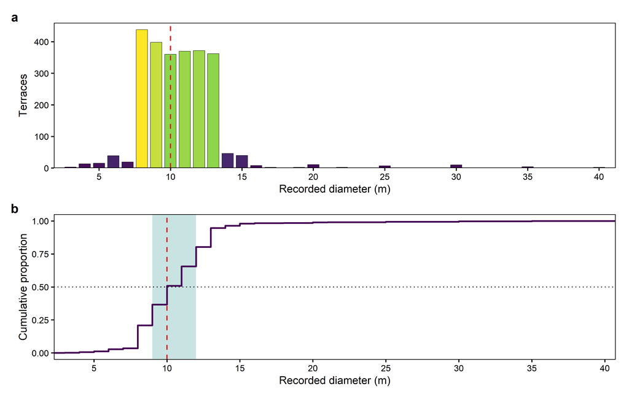

```r
# 12. Figure 3 plot
p3a <- ggplot(diam_freq, aes(Diameter_m, Terraces, fill = Terraces)) +
  geom_col(width = 0.8, colour = "black", linewidth = 0.15) +
  geom_vline(xintercept = diam_summary$Median, linetype = "dashed", colour = COL[["fit"]],
             linewidth = 0.45) +
  scale_fill_viridis_c(option = "viridis", guide = "none") +
  scale_x_continuous(breaks = seq(0, 40, 5), expand = expansion(mult = 0.02)) +
  scale_y_continuous(expand = expansion(mult = c(0, 0.05))) +
  labs(x = "Recorded diameter (m)", y = "Terraces") +
  theme_v7()
p3b <- ggplot(terraces, aes(Diameter_m)) +
  annotate("rect", xmin = diam_summary$Q1, xmax = diam_summary$Q3, ymin = -Inf, ymax = Inf,
           fill = tint(COL[["global"]], 0.75)) +
  geom_hline(yintercept = 0.5, linetype = "dotted", colour = COL[["neutral"]], linewidth = 0.35) +
  geom_vline(xintercept = diam_summary$Median, linetype = "dashed", colour = COL[["fit"]],
             linewidth = 0.45) +
  stat_ecdf(geom = "step", colour = COL[["observed"]], linewidth = 0.65) +
  scale_x_continuous(breaks = seq(0, 40, 5), expand = expansion(mult = 0.02)) +
  scale_y_continuous(breaks = seq(0, 1, 0.25), labels = scales::label_number(accuracy = 0.01)) +
  labs(x = "Recorded diameter (m)", y = "Cumulative proportion") +
  theme_v7()
p3 <- (p3a / p3b) + plot_annotation(tag_levels = "a")
print(p3)
```

```r
SAVED_FIGURES <- c(SAVED_FIGURES, save_figure(p3, "FIGURE_3", FIG_HEIGHT_MM[["FIGURE_3"]]))
```

**Fig. 3** Recorded diameters of the 2,526 Tairona terraces. (a) Number of terraces by diameter, with the median marked by the dashed red line. (b) Empirical cumulative distribution, with the interquartile range shaded and the median dashed

#### Figure 3. Numerical description

```r
# 14. Figure 3 report
report_start("Figure 3", "Distribution of recorded terrace diameters",
             paste("panel a terraces by diameter, panel b empirical cumulative distribution,",
                   "dashed line median, shaded band interquartile range"))
```

```
## REPORT=Figure 3; SHOWS=Distribution of recorded terrace diameters
## ENCODING=panel a terraces by diameter, panel b empirical cumulative distribution,
##     dashed line median, shaded band interquartile range
```

```r
emit_rows(N = n, MEAN_M = diam_summary$Mean, SD_M = diam_summary$SD,
          MEDIAN_M = diam_summary$Median, IQR_M = interval_text(diam_summary$Q1, diam_summary$Q3),
          MAD_M = diam_summary$MAD, RANGE_M = interval_text(diam_summary$Min, diam_summary$Max),
          P05_P95_M = interval_text(diam_summary$P05, diam_summary$P95),
          CV_PERCENT = diam_summary$CV, GINI_DIAMETER = diam_summary$Gini_D,
          GINI_AREA = diam_summary$Gini_area)
```

```
## N=2526; MEAN_M=10.65; SD_M=2.955; MEDIAN_M=10; IQR_M=9 to 12; MAD_M=2.965
##     RANGE_M=3 to 40; P05_P95_M=8 to 14; CV_PERCENT=27.75; GINI_DIAMETER=0.1294
##     GINI_AREA=0.2703
```

```r
emit_rows(DIAMETER_M = vector_text(diam_freq$Diameter_m), TERRACES = vector_text(diam_freq$Terraces))
```

```
## DIAMETER_M=3, 4, 5, 6, 7, 8, 9, 10, 11, 12, 13, 14, 15, 16, 17, 18, 19, 20, 21, 22, 25,
##     28, 30, 35, 40
##     TERRACES=3, 13, 15, 39, 19, 438, 398, 360, 370, 372, 362, 46, 40, 8, 2, 1, 2, 11,
##     1, 2, 7, 1, 10, 4, 2
```

```r
emit_text("RESULT", paste0(fmt_num(100 * diam_summary$Share_typical, 4), " percent of terraces ",
                           "measure ", TYPICAL_DIAMETER_M[1], " to ", TYPICAL_DIAMETER_M[2], " m"))
```

```
## RESULT=91.05 percent of terraces measure 8 to 13 m
```

## Figure 4. Spatial patterns of terrace size and local context

```r
# 16. Pairwise distances and close pairs
DM <- as.matrix(stats::dist(xy_local))
diag(DM) <- Inf
nn_dist <- DM[cbind(seq_len(n), max.col(-DM, ties.method = "first"))]
GAP <- DM - outer(D, D, "+") / 2
min_gap <- GAP[cbind(seq_len(n), max.col(-GAP, ties.method = "first"))]
overlap_pairs <- sum(GAP[upper.tri(GAP)] < 0)
rm(GAP)
close_audit <- do.call(rbind, lapply(c(2, 5, 10), function(r) {
  ij <- which(upper.tri(DM) & DM < r, arr.ind = TRUE)
  data.frame(Threshold_m = r, Pairs = nrow(ij), Terraces = length(unique(as.vector(ij))))
}))
close2 <- which(upper.tri(DM) & DM < CLOSE_LIMIT_M, arr.ind = TRUE)
component <- seq_len(n)
for (k in seq_len(nrow(close2))) {
  a <- component[close2[k, 1]]
  b <- component[close2[k, 2]]
  if (a != b) component[component == b] <- a
}
close_vertices <- sort(unique(as.vector(close2)))
close_groups <- split(close_vertices, component[close_vertices])
close_keep <- vapply(close_groups, min, integer(1))
keep_no_close <- setdiff(seq_len(n), close_vertices)
keep_one_close <- setdiff(seq_len(n), setdiff(close_vertices, close_keep))
```

```r
# 17. Local concentration
concentration <- function(radius) {
  count <- rowSums(DM <= radius)
  area <- rep(pi * radius^2, n)
  e <- which(edge_m < radius)
  if (length(e)) {
    buffers <- sf::st_buffer(sf::st_geometry(architecture[e, ]), radius, nQuadSegs = 60)
    for (k in seq_along(e)) {
      area[e[k]] <- sum(as.numeric(sf::st_area(suppressWarnings(
        sf::st_intersection(buffers[k], survey_union)))))
    }
  }
  if (any(!is.finite(area) | area <= 0)) stop("Invalid neighborhood area")
  data.frame(Radius_m = radius, Count = count, Area_ha = area / 1e4,
             Concentration = count / (area / 1e4))
}
conc <- setNames(lapply(CONCENTRATION_RADII_M, concentration), as.character(CONCENTRATION_RADII_M))
conc_audit <- do.call(rbind, lapply(conc, function(z) {
  data.frame(Radius_m = z$Radius_m[1], Median_count = stats::median(z$Count),
             P25 = qv(z$Concentration, .25), P75 = qv(z$Concentration, .75))
}))
primary <- conc[[as.character(PRIMARY_RADIUS_M)]]
```

```r
# 18. Figure 4 compute
win_sf <- sf::st_sf(geometry = survey_union)
region_hulls <- do.call(rbind, lapply(seq_len(LOO_REGIONS), function(g) {
  pts <- as.matrix(terraces[regions == g, c("X", "Y")])
  h <- grDevices::chull(pts)
  data.frame(Region = g, X = pts[h, 1], Y = pts[h, 2])
}))
region_labels <- data.frame(Region = seq_len(LOO_REGIONS),
                            X = as.numeric(tapply(terraces$X, regions, mean)),
                            Y = as.numeric(tapply(terraces$Y, regions, mean)))
diam_labels <- c(paste(fmt_num(min(D)), "to 7"), "8 to 9", "10 to 11", "12 to 13",
                 paste("14 to", fmt_num(max(D))))
map_pts <- data.frame(X = terraces$X, Y = terraces$Y, Diameter_m = D,
                      Class = cut(D, breaks = c(-Inf, 7, 9, 11, 13, Inf), labels = diam_labels),
                      Concentration = primary$Concentration, Region = regions)
log_d <- log(D)
near_matrix <- (DM < NEAR_MAX_M) * 1
near_n <- rowSums(near_matrix)
near_sq <- pmax(near_n * log_d^2 - 2 * log_d * as.numeric(near_matrix %*% log_d) +
                  as.numeric(near_matrix %*% log_d^2), 0)
rm(near_matrix)
all_sq <- (n - 1) * log_d^2 - 2 * log_d * (sum(log_d) - log_d) + (sum(log_d^2) - log_d^2)
if (any(!is.finite(all_sq) | all_sq <= 0)) stop("Invalid local variogram normalization")
map_pts$Neighbors <- near_n
map_pts$Local_vario <- ifelse(near_n > 0, (near_sq / pmax(near_n, 1)) / (all_sq / (n - 1)),
                              NA_real_)
map_pts$Local_shown <- ifelse(near_n >= MIN_LOCAL_NEIGHBORS, map_pts$Local_vario, NA_real_)
if (USE_DEM) {
  slope_masked <- terra::mask(ras[["slope"]], terra::vect(win_sf))
  rdf <- terra::as.data.frame(slope_masked, xy = TRUE, na.rm = TRUE)
  map_raster <- data.frame(X = rdf[[1]], Y = rdf[[2]], Value = rdf[[3]])
  raster_title <- paste0("Slope at ", DEM_SCALE_M, " m context (degrees)")
  MAP_D_TEXT <- paste0("Terrain slope at ", DEM_SCALE_M, " m context.")
} else {
  im_k <- spatstat.explore::density.ppp(Xpp, sigma = PCF_SIGMA_M, edge = TRUE, dimyx = 256)
  idf <- as.data.frame(im_k)
  idf <- idf[is.finite(idf$value), ]
  map_raster <- data.frame(X = idf$x + origin[1], Y = idf$y + origin[2], Value = idf$value * 1e6)
  raster_title <- paste0("Kernel intensity, bandwidth ", PCF_SIGMA_M, " m (terraces per km2)")
  MAP_D_TEXT <- paste0("Kernel intensity at a ", PCF_SIGMA_M, " m bandwidth.")
}
if (!nrow(map_raster) || any(!is.finite(map_raster$Value))) stop("Invalid map raster")
map_xlim <- as.numeric(bb[c("xmin", "xmax")])
map_ylim <- as.numeric(bb[c("ymin", "ymax")])
map_ylim[1] <- map_ylim[1] - 0.2 * diff(map_ylim)
map_layers <- function() {
  list(geom_polygon(data = region_hulls, aes(X, Y, group = Region), fill = NA,
                    colour = "grey30", linewidth = 0.25, linetype = "dashed", inherit.aes = FALSE),
       geom_sf(data = win_sf, fill = NA, colour = "black", linewidth = 0.35, inherit.aes = FALSE),
       geom_point(data = region_labels, aes(X, Y), shape = 21, fill = "white",
                  colour = "black", size = 3.4, stroke = 0.25, inherit.aes = FALSE),
       geom_text(data = region_labels, aes(X, Y, label = Region), size = 2.3,
                 fontface = "bold", colour = "black", inherit.aes = FALSE),
       ggspatial::annotation_scale(location = "bl", width_hint = 0.4, text_cex = 0.6,
                                   height = grid::unit(0.18, "cm")),
       ggspatial::annotation_north_arrow(location = "bl", which_north = "true",
                                         pad_x = grid::unit(0.0, "in"),
                                         pad_y = grid::unit(0.2, "in"),
                                         height = grid::unit(0.9, "cm"),
                                         width = grid::unit(0.9, "cm"),
                                         style = ggspatial::north_arrow_fancy_orienteering),
       coord_sf(crs = sf::st_crs(EXPECTED_CRS), xlim = map_xlim, ylim = map_ylim, datum = NA),
       theme_v7(),
       theme(axis.title = element_blank(), axis.text = element_blank(),
             axis.ticks = element_blank(), panel.border = element_blank(),
             panel.grid = element_blank(), panel.background = element_blank(),
             legend.key.width = grid::unit(7, "mm"), legend.key.height = grid::unit(2.6, "mm")))
}
class_order <- order(match(as.character(map_pts$Class), levels(map_pts$Class)[c(3, 2, 4, 1, 5)]))
```

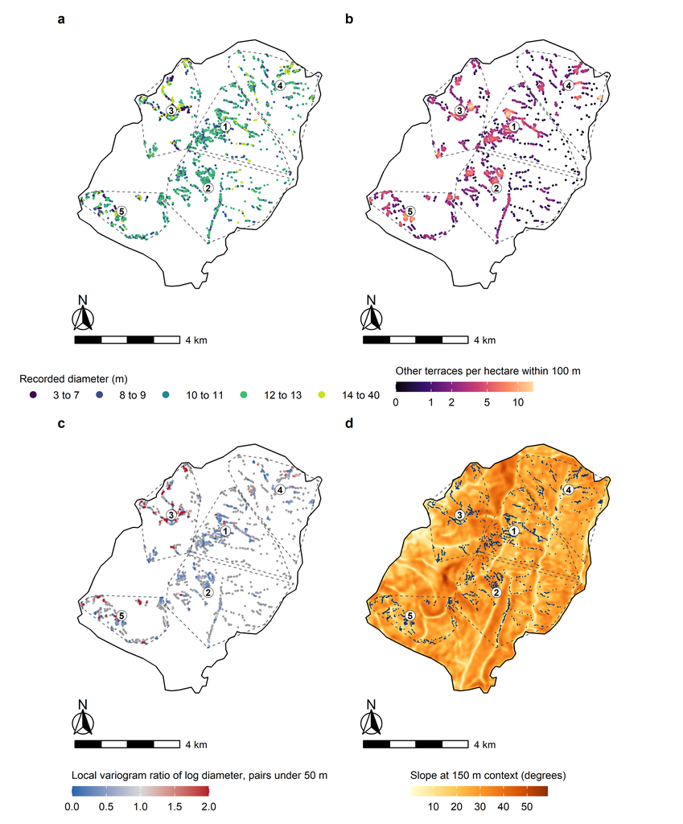

```r
# 19. Figure 4 plot
p4a <- ggplot(map_pts[class_order, ], aes(X, Y)) +
  geom_point(aes(colour = Class), size = 0.45, shape = 16) +
  scale_colour_viridis_d(option = "viridis", end = 0.92, drop = FALSE,
                         name = "Recorded diameter (m)") +
  guides(colour = guide_legend(nrow = 1, override.aes = list(size = 2.2))) +
  map_layers()
p4b <- ggplot(map_pts[order(map_pts$Concentration), ], aes(X, Y)) +
  geom_point(aes(colour = Concentration), size = 0.45, shape = 16) +
  scale_colour_viridis_c(option = "magma", end = 0.92, transform = "log1p",
                         breaks = c(0, 1, 2, 5, 10),
                         name = paste0("Other terraces per hectare within ", PRIMARY_RADIUS_M,
                                       " m")) +
  map_layers()
p4c <- ggplot(map_pts[order(!is.na(map_pts$Local_shown), abs(map_pts$Local_shown - 1)), ],
              aes(X, Y)) +
  geom_point(aes(colour = Local_shown), size = 0.45, shape = 16) +
  scale_colour_gradient2(low = "#2166AC", mid = "grey85", high = "#B2182B", midpoint = 1,
                         limits = c(0, 2), oob = scales::squish, na.value = "grey60",
                         name = paste0("Local variogram ratio of log diameter, pairs under ",
                                       NEAR_MAX_M, " m")) +
  map_layers()
p4d <- ggplot(map_raster, aes(X, Y)) +
  geom_raster(aes(fill = Value)) +
  geom_point(data = map_pts, aes(X, Y), size = 0.1, shape = 16, colour = "#08306B",
             inherit.aes = FALSE) +
  scale_fill_distiller(palette = "YlOrBr", direction = 1, name = raster_title) +
  map_layers()
p4 <- (p4a | p4b) / (p4c | p4d) + plot_annotation(tag_levels = "a")
print(p4)
```

```r
SAVED_FIGURES <- c(SAVED_FIGURES, save_figure(p4, "FIGURE_4", FIG_HEIGHT_MM[["FIGURE_4"]]))
```

**Fig. 4** Terrace size and local context. (a) Recorded diameter by class. (b) Other terraces per hectare within 100 m. (c) Local variogram of log diameter for pairs under 50 m divided by its value for all other terraces; below 1, neighbors more alike; grey, fewer than 3 neighbors. (d) Terrain slope at 150 m context. Dashed outlines, analytical labeling regions

#### Figure 4. Numerical description

```r
# 21. Figure 4 report
report_start("Figure 4", "Spatial patterns of terrace size and local context",
             paste("panel a diameter class, panel b other terraces per hectare within 100 m,",
                   "panel c local variogram ratio of log diameter for pairs under 50 m, panel d",
                   "terrain slope or kernel intensity, dashed outlines labeling regions"))
```

```
## REPORT=Figure 4; SHOWS=Spatial patterns of terrace size and local context
## ENCODING=panel a diameter class, panel b other terraces per hectare within 100 m, panel
##     c local variogram ratio of log diameter for pairs under 50 m, panel d terrain slope
##     or kernel intensity, dashed outlines labeling regions
```

```r
emit_rows(DIAMETER_CLASS_M = levels(map_pts$Class), TERRACES = as.integer(table(map_pts$Class)))
```

```
## DIAMETER_CLASS_M=3 to 7; TERRACES=89
## DIAMETER_CLASS_M=8 to 9; TERRACES=836
## DIAMETER_CLASS_M=10 to 11; TERRACES=730
## DIAMETER_CLASS_M=12 to 13; TERRACES=734
## DIAMETER_CLASS_M=14 to 40; TERRACES=137
```

```r
lv <- map_pts$Local_shown[is.finite(map_pts$Local_shown)]
emit_rows(NEAR_RANGE_M = paste0("0-", NEAR_MAX_M), MIN_NEIGHBORS_SHOWN = MIN_LOCAL_NEIGHBORS,
          WITH_ANY_NEIGHBOR = sum(near_n > 0), SHOWN = length(lv))
```

```
## NEAR_RANGE_M=0-50; MIN_NEIGHBORS_SHOWN=3; WITH_ANY_NEIGHBOR=2281; SHOWN=1570
```

```r
emit_rows(MEDIAN_LOCAL_RATIO = stats::median(lv), MEAN_LOCAL_RATIO = mean(lv),
          SHARE_BELOW_1 = mean(lv < 1), SHARE_ZERO = mean(lv == 0), SHARE_ABOVE_2 = mean(lv > 2),
          P05_P95 = interval_text(qv(lv, .05), qv(lv, .95), 3))
```

```
## MEDIAN_LOCAL_RATIO=0.6679; MEAN_LOCAL_RATIO=0.8732; SHARE_BELOW_1=0.7611; SHARE_ZERO=0
##     SHARE_ABOVE_2=0.05223; P05_P95=0.203 to 2.06
```

```r
emit_rows(REGION = seq_len(LOO_REGIONS), TERRACES = tabulate(regions, LOO_REGIONS),
          MEDIAN_DIAMETER_M = as.numeric(tapply(D, regions, stats::median)),
          MEDIAN_CONCENTRATION_PER_HA = as.numeric(tapply(primary$Concentration, regions,
                                                          stats::median)),
          SHOWN = as.numeric(tapply(is.finite(map_pts$Local_shown), regions, sum)),
          MEDIAN_LOCAL_RATIO = as.numeric(tapply(map_pts$Local_shown, regions, stats::median,
                                                 na.rm = TRUE)),
          SHARE_BELOW_1 = as.numeric(tapply(map_pts$Local_shown < 1, regions, mean,
                                            na.rm = TRUE)))
```

```
## REGION=1; TERRACES=608; MEDIAN_DIAMETER_M=10; MEDIAN_CONCENTRATION_PER_HA=2.865
##     SHOWN=363; MEDIAN_LOCAL_RATIO=0.5721; SHARE_BELOW_1=0.8567
## REGION=2; TERRACES=581; MEDIAN_DIAMETER_M=11; MEDIAN_CONCENTRATION_PER_HA=2.228
##     SHOWN=317; MEDIAN_LOCAL_RATIO=0.6241; SHARE_BELOW_1=0.8864
## REGION=3; TERRACES=507; MEDIAN_DIAMETER_M=10; MEDIAN_CONCENTRATION_PER_HA=3.183
##     SHOWN=352; MEDIAN_LOCAL_RATIO=0.8399; SHARE_BELOW_1=0.5767
## REGION=4; TERRACES=404; MEDIAN_DIAMETER_M=11; MEDIAN_CONCENTRATION_PER_HA=2.546
##     SHOWN=241; MEDIAN_LOCAL_RATIO=0.6517; SHARE_BELOW_1=0.8216
## REGION=5; TERRACES=426; MEDIAN_DIAMETER_M=10; MEDIAN_CONCENTRATION_PER_HA=3.501
##     SHOWN=297; MEDIAN_LOCAL_RATIO=0.6883; SHARE_BELOW_1=0.6801
```

```r
if (USE_DEM) {
  emit_rows(SLOPE_AT_TERRACES_MEDIAN_DEG = stats::median(terrain_raw$slope),
            SLOPE_AT_TERRACES_P05_P95 = interval_text(qv(terrain_raw$slope, .05),
                                                      qv(terrain_raw$slope, .95), 3),
            SLOPE_IN_WINDOW_P05_P95 = interval_text(qv(map_raster$Value, .05),
                                                    qv(map_raster$Value, .95), 3))
}
```

```
## SLOPE_AT_TERRACES_MEDIAN_DEG=22.47; SLOPE_AT_TERRACES_P05_P95=8.59 to 33
##     SLOPE_IN_WINDOW_P05_P95=10.1 to 37.9
```

```r
emit_text("NOTE", paste("Maps are drawn in EPSG:", EXPECTED_CRS, "without coordinate labels, with",
                        "true north and a scale bar. Local ratios follow the normalization of the",
                        "local mark variogram of Eckardt and Moradi (2026), averaged over pairs",
                        "under 50 m; they are descriptive and are not tested individually"))
```

```
## NOTE=Maps are drawn in EPSG: 32618 without coordinate labels, with true north and a
##     scale bar. Local ratios follow the normalization of the local mark variogram of
##     Eckardt and Moradi (2026), averaged over pairs under 50 m, they are descriptive and
##     are not tested individually
```

## Figure 5. Spacing and multiscale aggregation

```r
# 23. Figure 5 pcf
make_envelope <- function(obs, sims, x, label) {
  stopifnot(length(obs) == length(x), ncol(sims) == length(x), all(is.finite(obs)),
            all(is.finite(sims)))
  cs <- GET::create_curve_set(list(r = x, obs = obs, sim_m = t(sims)))
  e <- GET::global_envelope_test(cs, type = "erl", alternative = "two.sided", alpha = ALPHA)
  p <- as.numeric(attr(e, "p"))
  if (length(p) != 1L || !is.finite(p)) stop("Global envelope p value unavailable for ", label)
  data.frame(Test = label, Distance_m = x, Observed = as.numeric(e$obs),
             Reference = as.numeric(e$central), Low = as.numeric(e$lo), High = as.numeric(e$hi),
             P_global = p, B = nrow(sims), Outside = obs < e$lo | obs > e$hi)
}
pcf_curve <- function(P, sigma, bw, r, correction, zero = "convolution") {
  lam <- spatstat.explore::density.ppp(P, sigma = sigma, at = "points", edge = TRUE,
                                       leaveoneout = TRUE)
  lam <- pmax(as.numeric(lam), P$n / spatstat.geom::area.owin(P$window) * 1e-4)
  f <- spatstat.explore::pcfinhom(P, lambda = lam, r = r, bw = bw, correction = correction,
                                  divisor = "d", kernel = "epanechnikov", zerocor = zero,
                                  adaptive = FALSE, renormalise = TRUE, normpower = 2)
  z <- if (correction == "translate") f$trans else f$iso
  if (length(z) != length(r) || any(!is.finite(z[-1L]))) stop("Invalid PCF estimate")
  as.numeric(z[-1L])
}
environment(pcf_curve) <- baseenv()
fit_intensity <- function(P, sigma) {
  im <- spatstat.explore::density.ppp(P, sigma = sigma, edge = TRUE, dimyx = 256)
  ok <- is.finite(im$v)
  im$v[ok] <- pmax(im$v[ok], P$n / spatstat.geom::area.owin(P$window) * 1e-4)
  im
}
environment(fit_intensity) <- baseenv()
sim_kernel <- function(n, intensity, win) {
  P <- spatstat.random::rpoint(n, f = intensity, win = win, forcewin = TRUE)
  if (P$n != n || !identical(P$window$type, win$type) ||
      abs(spatstat.geom::area.owin(P$window) - spatstat.geom::area.owin(win)) > 1e-6 ||
      !all(spatstat.geom::inside.owin(P$x, P$y, win))) {
    stop("Kernel simulation did not retain the observation window")
  }
  P
}
environment(sim_kernel) <- baseenv()
pcf_step <- function(k, p) {
  s <- p$simulate(p$n, p$intensity, p$window)
  p$curve(s, p$sigma, p$bw, p$r, p$correction, p$zero)
}
run_pcf <- function(sigma, bw, correction, B, seed, label, r = PCF_R_M, zero = "convolution") {
  obs <- pcf_curve(Xpp, sigma, bw, r, correction, zero)
  sim <- mc_run(B, pcf_step, list(n = n, intensity = fit_intensity(Xpp, sigma), window = W,
                                  sigma = sigma, bw = bw, r = r, correction = correction,
                                  zero = zero, curve = pcf_curve, simulate = sim_kernel),
                seed, label)
  out <- make_envelope(obs, sim, r[-1L], label)
  attr(out, "simulation_matrix") <- sim
  out
}
pcf_main <- run_pcf(PCF_SIGMA_M, PCF_BW_M, "translate", N_SIM, SEED + 100000L,
                    "Broad PCF, kernel intensity")
cal_step <- function(k, p) {
  z <- p$simulate(p$n, p$im, p$W)
  obs <- p$curve(z, p$sigma, p$bw, p$r, "translate")
  iz <- p$intensity(z, p$sigma)
  inner <- replicate(p$inner, {
    zz <- p$simulate(p$n, iz, p$W)
    p$curve(zz, p$sigma, p$bw, p$r, "translate")
  })
  p$score(obs, t(inner))$score
}
max_discrepancy <- function(obs, sim) {
  center <- colMeans(sim)
  scale <- apply(sim, 2L, stats::sd)
  scale <- pmax(scale, 1e-8 * pmax(1, abs(center)))
  if (length(obs) != length(center) || any(!is.finite(c(obs, center, scale)))) {
    stop("Invalid calibration curves")
  }
  list(score = max(abs((obs - center) / scale)), center = center, scale = scale)
}
environment(max_discrepancy) <- baseenv()
pcf_calibrated <- NULL
calibration <- data.frame(Status = "disabled", Outer = 0L, Inner = 0L, P = NA_real_,
                          Observed_score = NA_real_, Critical_score = NA_real_)
if (RUN_CALIBRATION) {
  obs_cal <- max_discrepancy(pcf_main$Observed,
                             attr(pcf_main, "simulation_matrix")[seq_len(N_CAL_INNER), ,
                                                                 drop = FALSE])
  outer_scores <- as.numeric(mc_run(N_CAL_OUTER, cal_step,
                                    list(n = n, im = fit_intensity(Xpp, PCF_SIGMA_M), W = W,
                                         curve = pcf_curve, intensity = fit_intensity,
                                         sigma = PCF_SIGMA_M, bw = PCF_BW_M, r = PCF_R_M,
                                         inner = N_CAL_INNER, simulate = sim_kernel,
                                         score = max_discrepancy),
                                    SEED + 1800000L, "Broad PCF, nested calibration"))
  p_cal <- (1 + sum(outer_scores >= obs_cal$score)) / (N_CAL_OUTER + 1)
  crit_index <- ceiling((N_CAL_OUTER + 1) * (1 - ALPHA))
  crit <- if (crit_index <= N_CAL_OUTER) sort(outer_scores)[crit_index] else Inf
  outside_cal <- abs((pcf_main$Observed - obs_cal$center) / obs_cal$scale) > crit
  if (!identical(p_cal <= ALPHA, any(outside_cal))) {
    stop("Calibrated p value and envelope disagree")
  }
  pcf_calibrated <- data.frame(Test = "Broad PCF, kernel intensity, calibrated",
                               Distance_m = pcf_main$Distance_m, Observed = pcf_main$Observed,
                               Reference = obs_cal$center,
                               Low = obs_cal$center - crit * obs_cal$scale,
                               High = obs_cal$center + crit * obs_cal$scale, P_global = p_cal,
                               B = N_CAL_OUTER, Outside = outside_cal)
  calibration <- data.frame(Status = "nested", Outer = N_CAL_OUTER, Inner = N_CAL_INNER,
                            P = p_cal, Observed_score = obs_cal$score, Critical_score = crit)
}
PCF_FINE_BW_M <- 0.15 / sqrt(n / spatstat.geom::area.owin(W)) / sqrt(5)
lam_cv <- pmax(as.numeric(spatstat.explore::density.ppp(Xpp, sigma = PCF_SIGMA_M, at = "points",
                                                        edge = TRUE, leaveoneout = TRUE)),
               n / spatstat.geom::area.owin(W) * 1e-4)
bw_cv <- tryCatch(as.numeric(spatstat.explore::bw.pcfinhom(Xpp, lambda = lam_cv,
                                                           rmax = max(PCF_FINE_R_M),
                                                           cv.method = "compLik",
                                                           kernel = "epanechnikov",
                                                           divisor = "d",
                                                           zerocor = "convolution"))[1],
                  error = function(e) NA_real_)
if (!is.finite(bw_cv) || bw_cv <= 0) bw_cv <- NA_real_
pcf_fine <- run_pcf(PCF_SIGMA_M, PCF_FINE_BW_M, "translate", N_SIM, SEED + 2600000L,
                    "Fine PCF, kernel intensity", PCF_FINE_R_M)
pcf_fine_jf <- run_pcf(PCF_SIGMA_M, PCF_FINE_BW_M, "translate", N_SENS, SEED + 2620000L,
                       "Fine PCF, Jones-Foster correction", PCF_FINE_R_M, "JonesFoster")
pcf_fine_cv <- if (is.finite(bw_cv)) {
  run_pcf(PCF_SIGMA_M, bw_cv, "translate", N_SENS, SEED + 2640000L,
          "Fine PCF, cross-validated bandwidth", PCF_FINE_R_M)
} else NULL
pcf_fine_wide <- run_pcf(PCF_SIGMA_M, 1.5 * PCF_FINE_BW_M, "translate", N_SENS,
                         SEED + 2660000L, "Fine PCF, 1.5 times bandwidth", PCF_FINE_R_M)
```

```r
# 24. Figure 5 models
trend <- if (USE_DEM_INTENSITY) ~ elev + slope + tpi else ~ I(x / 1000) + I(y / 1000)
environment(trend) <- baseenv()
trend_label <- if (USE_DEM_INTENSITY) "terrain trend" else "coordinate trend"
model_cov <- if (length(terrain_cov)) terrain_cov else NULL
fit_poisson <- function(P, tr, cov) spatstat.model::ppm(P, trend = tr, covariates = cov)
environment(fit_poisson) <- baseenv()
fit_thomas <- function(P, tr, cov) {
  spatstat.model::kppm(P, trend = tr, covariates = cov, clusters = "Thomas", statistic = "K")
}
environment(fit_thomas) <- baseenv()
poisson_fit <- fit_poisson(Xpp, trend, model_cov)
thomas_fit <- tryCatch(fit_thomas(Xpp, trend, model_cov), error = function(e) e)
model_curve <- function(P, tr, cov, bw, r) {
  m <- spatstat.model::ppm(P, trend = tr, covariates = cov)
  z <- spatstat.explore::pcfinhom(P, lambda = m, update = FALSE, leaveoneout = FALSE, r = r,
                                  bw = bw, correction = "translate", divisor = "d",
                                  kernel = "epanechnikov", zerocor = "convolution",
                                  adaptive = FALSE, renormalise = TRUE, normpower = 2)
  as.numeric(z$trans[-1L])
}
environment(model_curve) <- baseenv()
model_step <- function(k, p) {
  if (!requireNamespace("spatstat.model", quietly = TRUE)) stop("spatstat.model is unavailable")
  P <- stats::simulate(p$fit, nsim = 1, drop = TRUE)
  if (!inherits(P, "ppp")) P <- P[[1L]]
  p$curve(P, p$trend, p$cov, p$bw, p$r)
}
run_model <- function(fit, label, seed, bw = PCF_BW_M, r = PCF_R_M) {
  sims <- mc_run(N_MODEL, model_step, list(fit = fit, curve = model_curve, trend = trend,
                                           cov = model_cov, bw = bw, r = r), seed, label)
  make_envelope(model_curve(Xpp, trend, model_cov, bw, r), sims, r[-1L], label)
}
poisson_diag <- run_model(poisson_fit, paste("Broad PCF, Poisson,", trend_label),
                          SEED + 2100000L)
thomas_diag <- NULL
thomas_fine <- NULL
thomas_par <- NULL
if (!inherits(thomas_fit, "error")) {
  thomas_diag <- run_model(thomas_fit, paste("Broad PCF, Thomas,", trend_label), SEED + 2200000L)
  thomas_fine <- run_model(thomas_fit, paste("Fine PCF, Thomas,", trend_label), SEED + 2680000L,
                           PCF_FINE_BW_M, PCF_FINE_R_M)
  cp <- thomas_fit$clustpar
  if (!is.null(cp)) {
    parents <- cp[["kappa"]] * spatstat.geom::area.owin(W)
    thomas_par <- data.frame(Kappa_per_km2 = cp[["kappa"]] * 1e6, Scale_m = cp[["scale"]],
                             Parents = parents, Mean_cluster_size = n / parents)
  }
}
```

```r
# 25. Figure 5 sensitivity
pcf_sens <- list(
  run_pcf(PCF_SIGMA_M / 2, PCF_BW_M, "translate", N_SENS, SEED + 1100000L,
          "Broad PCF, kernel bandwidth 250 m"),
  run_pcf(PCF_SIGMA_M * 2, PCF_BW_M, "translate", N_SENS, SEED + 1110000L,
          "Broad PCF, kernel bandwidth 1000 m"),
  run_pcf(PCF_SIGMA_M, PCF_BW_M * 2, "translate", N_SENS, SEED + 1120000L,
          "Broad PCF, pair bandwidth 40 m"),
  run_pcf(PCF_SIGMA_M, PCF_BW_M, "Ripley", N_SENS, SEED + 1130000L,
          "Broad PCF, isotropic correction"))
orientation_stat <- function(P) {
  cp <- spatstat.geom::closepairs(P, rmax = 500, twice = FALSE, what = "all")
  ok <- cp$d >= 100
  a <- (atan2(cp$dy[ok], cp$dx[ok]) * 180 / pi) %% 180
  v <- tabulate(findInterval(a, seq(0, 180, 30)), 6L)
  if (!sum(v)) stop("No pairs in the orientation domain")
  v / sum(v)
}
environment(orientation_stat) <- baseenv()
orientation_step <- function(k, p) p$stat(p$simulate(p$n, p$intensity, p$W))
ori_sim <- mc_run(N_SENS, orientation_step, list(n = n, intensity = fit_intensity(Xpp, PCF_SIGMA_M),
                                                 W = W, stat = orientation_stat,
                                                 simulate = sim_kernel),
                  SEED + 2500000L, "Pair orientation")
ori <- make_envelope(orientation_stat(Xpp), ori_sim, seq(15, 165, 30), "Pair orientation")
```

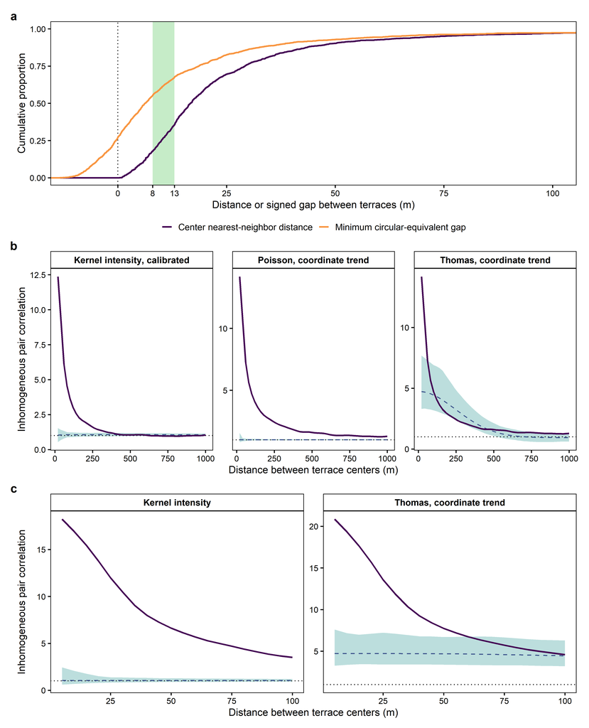

```r
# 26. Figure 5 plot
spacing_df <- rbind(data.frame(Metric = "Center nearest-neighbor distance", Value = nn_dist),
                    data.frame(Metric = "Minimum circular-equivalent gap", Value = min_gap))
p5a <- ggplot(spacing_df, aes(Value, colour = Metric)) +
  annotate("rect", xmin = TYPICAL_DIAMETER_M[1], xmax = TYPICAL_DIAMETER_M[2], ymin = -Inf,
           ymax = Inf, fill = tint(COL[["regional"]], 0.65)) +
  geom_vline(xintercept = 0, linetype = "dotted", colour = COL[["neutral"]], linewidth = 0.35) +
  stat_ecdf(geom = "step", linewidth = 0.65) +
  scale_colour_manual(values = c("Center nearest-neighbor distance" = COL[["observed"]],
                                 "Minimum circular-equivalent gap" = COL[["outside"]]),
                      name = NULL) +
  scale_x_continuous(breaks = c(0, TYPICAL_DIAMETER_M, 25, 50, 75, 100)) +
  scale_y_continuous(breaks = seq(0, 1, 0.25), labels = scales::label_number(accuracy = 0.01)) +
  coord_cartesian(xlim = c(-10, 100)) +
  labs(x = "Distance or signed gap between terraces (m)", y = "Cumulative proportion") +
  theme_v7()
pcf_panel <- function(df) {
  ggplot(df, aes(Distance_m, Observed)) +
    geom_ribbon(aes(ymin = Low, ymax = High), fill = tint(COL[["global"]], 0.7)) +
    geom_hline(yintercept = 1, linetype = "dotted", colour = COL[["neutral"]], linewidth = 0.35) +
    geom_line(aes(y = Reference), colour = COL[["reference"]], linetype = "dashed",
              linewidth = 0.4) +
    geom_line(colour = COL[["observed"]], linewidth = 0.65) +
    facet_wrap(~ Panel, nrow = 1, scales = "free_y") +
    labs(x = "Distance between terrace centers (m)", y = "Inhomogeneous pair correlation") +
    theme_v7()
}
with_panel <- function(df, panel) { df$Panel <- panel; df }
kernel_broad <- if (is.null(pcf_calibrated)) pcf_main else pcf_calibrated
broad_df <- rbind(with_panel(kernel_broad, if (is.null(pcf_calibrated)) "Kernel intensity" else
                    "Kernel intensity, calibrated"),
                  with_panel(poisson_diag, paste("Poisson,", trend_label)),
                  if (!is.null(thomas_diag)) with_panel(thomas_diag, paste("Thomas,", trend_label)))
broad_df$Panel <- factor(broad_df$Panel, levels = unique(broad_df$Panel))
fine_df <- rbind(with_panel(pcf_fine, "Kernel intensity"),
                 if (!is.null(thomas_fine)) with_panel(thomas_fine, paste("Thomas,", trend_label)))
fine_df$Panel <- factor(fine_df$Panel, levels = unique(fine_df$Panel))
p5 <- (p5a / pcf_panel(broad_df) / pcf_panel(fine_df)) +
  plot_layout(heights = c(0.9, 1, 1)) + plot_annotation(tag_levels = "a")
print(p5)
```

```r
SAVED_FIGURES <- c(SAVED_FIGURES, save_figure(p5, "FIGURE_5", FIG_HEIGHT_MM[["FIGURE_5"]]))
```

**Fig. 5** Spacing and aggregation of terrace centers. (a) Cumulative distributions of nearest-neighbor distance and minimum circular-equivalent gap; shading marks 8 to 13 m. (b) Inhomogeneous pair correlation function to 1 km under kernel, Poisson and Thomas references. (c) Fine-scale estimate to 100 m. Shaded areas are 95% global envelopes and dashed lines simulation means

#### Figure 5. Numerical description

```r
# 28. Figure 5 report
report_start("Figure 5", "Spacing and multiscale aggregation of terrace centers",
             paste("panel a cumulative distributions of nearest-neighbor distance and minimum",
                   "gap, panels b and c observed pair correlation, 95 percent global envelope",
                   "and simulation mean"))
```

```
## REPORT=Figure 5; SHOWS=Spacing and multiscale aggregation of terrace centers
## ENCODING=panel a cumulative distributions of nearest-neighbor distance and minimum gap,
##     panels b and c observed pair correlation, 95 percent global envelope and simulation
##     mean
```

```r
emit_rows(MIN_NN_M = min(nn_dist), P10_NN_M = qv(nn_dist, .10), MEDIAN_NN_M = stats::median(nn_dist),
          P90_NN_M = qv(nn_dist, .90), MEDIAN_MIN_GAP_M = stats::median(min_gap),
          NEGATIVE_GAP_TERRACES = sum(min_gap < 0), OVERLAPPING_PAIRS = overlap_pairs)
```

```
## MIN_NN_M=0.3934; P10_NN_M=5.623; MEDIAN_NN_M=16.68; P90_NN_M=48.64
##     MEDIAN_MIN_GAP_M=6.215; NEGATIVE_GAP_TERRACES=688; OVERLAPPING_PAIRS=478
```

```r
emit_rows(CLOSE_PAIRS_UNDER_M = close_audit$Threshold_m, PAIRS = close_audit$Pairs,
          TERRACES = close_audit$Terraces)
```

```
## CLOSE_PAIRS_UNDER_M=2; PAIRS=30; TERRACES=51
## CLOSE_PAIRS_UNDER_M=5; PAIRS=139; TERRACES=223
## CLOSE_PAIRS_UNDER_M=10; PAIRS=425; TERRACES=629
```

```r
emit_rows(GROUPS_UNDER_2_M = length(close_groups), TERRACES_IN_GROUPS = length(close_vertices),
          N_WITHOUT_GROUPS = length(keep_no_close), N_ONE_PER_GROUP = length(keep_one_close))
```

```
## GROUPS_UNDER_2_M=23; TERRACES_IN_GROUPS=51; N_WITHOUT_GROUPS=2475; N_ONE_PER_GROUP=2498
```

```r
emit_rows(BROAD_BW_M = PCF_BW_M, BROAD_HALFWIDTH_M = sqrt(5) * PCF_BW_M,
          FINE_BW_M = PCF_FINE_BW_M, FINE_HALFWIDTH_M = sqrt(5) * PCF_FINE_BW_M,
          CV_BW_M = bw_cv, KERNEL_SIGMA_M = PCF_SIGMA_M)
```

```
## BROAD_BW_M=20; BROAD_HALFWIDTH_M=44.72; FINE_BW_M=9.643; FINE_HALFWIDTH_M=21.56
##     CV_BW_M=7.028; KERNEL_SIGMA_M=500
```

```r
emit_rows(CALIBRATION = calibration$Status, OUTER = calibration$Outer, INNER = calibration$Inner,
          P_CALIBRATED = fmt_p(calibration$P), OBSERVED_SCORE = calibration$Observed_score,
          CRITICAL_SCORE = calibration$Critical_score)
```

```
## CALIBRATION=nested; OUTER=199; INNER=99; P_CALIBRATED=0.005; OBSERVED_SCORE=117.8
##     CRITICAL_SCORE=5.163
```

```r
broad_tests <- Filter(Negate(is.null), list(pcf_calibrated, pcf_main, poisson_diag, thomas_diag))
emit_rows(BROAD_TEST = vapply(broad_tests, function(e) e$Test[1], character(1)),
          P = fmt_p(vapply(broad_tests, function(e) e$P_global[1], numeric(1))),
          B = vapply(broad_tests, function(e) e$B[1], numeric(1)),
          OUTSIDE_M = vapply(broad_tests, function(e) outside_runs(e$Distance_m, e$Outside),
                             character(1)),
          G_AT_20_100_200_M = vapply(broad_tests, function(e) vector_text(value_at(e, c(20, 100, 200)),
                                                                          4), character(1)))
```

```
## BROAD_TEST=Broad PCF, kernel intensity, calibrated; P=0.005; B=199
##     OUTSIDE_M=20-360,740,780-820; G_AT_20_100_200_M=12.37, 3.646, 1.962
## BROAD_TEST=Broad PCF, kernel intensity; P=0.0003; B=10000; OUTSIDE_M=20-380
##     G_AT_20_100_200_M=12.37, 3.646, 1.962
## BROAD_TEST=Broad PCF, Poisson, coordinate trend; P=0.001; B=999; OUTSIDE_M=20-1000
##     G_AT_20_100_200_M=14.19, 4.718, 2.819
## BROAD_TEST=Broad PCF, Thomas, coordinate trend; P=0.014; B=999; OUTSIDE_M=20-40
##     G_AT_20_100_200_M=14.19, 4.718, 2.819
```

```r
fine_tests <- Filter(Negate(is.null), list(pcf_fine, pcf_fine_jf, pcf_fine_cv, pcf_fine_wide,
                                           thomas_fine))
emit_rows(FINE_TEST = vapply(fine_tests, function(e) e$Test[1], character(1)),
          P = fmt_p(vapply(fine_tests, function(e) e$P_global[1], numeric(1))),
          B = vapply(fine_tests, function(e) e$B[1], numeric(1)),
          OUTSIDE_M = vapply(fine_tests, function(e) outside_runs(e$Distance_m, e$Outside),
                             character(1)),
          G_AT_5_25_50_100_M = vapply(fine_tests, function(e) vector_text(value_at(e, c(5, 25, 50,
                                                                                      100)), 4),
                                      character(1)))
```

```
## FINE_TEST=Fine PCF, kernel intensity; P=0.0001; B=10000; OUTSIDE_M=5-100
##     G_AT_5_25_50_100_M=18.24, 11.99, 6.625, 3.505
## FINE_TEST=Fine PCF, Jones-Foster correction; P=0.001; B=1000; OUTSIDE_M=5-100
##     G_AT_5_25_50_100_M=21.19, 11.99, 6.624, 3.505
## FINE_TEST=Fine PCF, cross-validated bandwidth; P=0.001; B=1000; OUTSIDE_M=5-100
##     G_AT_5_25_50_100_M=19.31, 11.67, 6.5, 3.509
## FINE_TEST=Fine PCF, 1.5 times bandwidth; P=0.001; B=1000; OUTSIDE_M=5-100
##     G_AT_5_25_50_100_M=16.35, 12.22, 6.88, 3.554
## FINE_TEST=Fine PCF, Thomas, coordinate trend; P=0.002; B=999; OUTSIDE_M=5-55
##     G_AT_5_25_50_100_M=20.87, 13.58, 7.752, 4.603
```

```r
if (!is.null(thomas_par)) {
  emit_rows(THOMAS_KAPPA_PER_KM2 = thomas_par$Kappa_per_km2, THOMAS_SCALE_M = thomas_par$Scale_m,
            EXPECTED_PARENTS = thomas_par$Parents, MEAN_CLUSTER_SIZE = thomas_par$Mean_cluster_size)
}
```

```
## THOMAS_KAPPA_PER_KM2=0.7202; THOMAS_SCALE_M=176.1; EXPECTED_PARENTS=37.59
##     MEAN_CLUSTER_SIZE=67.2
```

```r
if (!is.null(thomas_fine)) {
  emit_text("RESULT", paste0("The fine-scale pair correlation exceeds the Thomas reference at ",
                             outside_runs(thomas_fine$Distance_m, thomas_fine$Outside), " m (p = ",
                             fmt_p(thomas_fine$P_global[1]), ")"))
}
```

```
## RESULT=The fine-scale pair correlation exceeds the Thomas reference at 5-55 m (p =
##     0.002)
```

```r
emit_text("NOTE", paste("Only the broad kernel test is calibrated; Poisson, Thomas and fine-scale",
                        "envelopes are approximate fitted-null diagnostics"))
```

```
## NOTE=Only the broad kernel test is calibrated, Poisson, Thomas and fine-scale envelopes
##     are approximate fitted-null diagnostics
```

```r
emit_rows(PCF_TEST = vapply(pcf_sens, function(e) e$Test[1], character(1)),
          P = fmt_p(vapply(pcf_sens, function(e) e$P_global[1], numeric(1))),
          OUTSIDE_M = vapply(pcf_sens, function(e) outside_runs(e$Distance_m, e$Outside),
                             character(1)),
          G_AT_20_100_M = vapply(pcf_sens, function(e) vector_text(value_at(e, c(20, 100)), 4),
                                 character(1)))
```

```
## PCF_TEST=Broad PCF, kernel bandwidth 250 m; P=0.003; OUTSIDE_M=20-240,600
##     G_AT_20_100_M=9.129, 2.516
## PCF_TEST=Broad PCF, kernel bandwidth 1000 m; P=0.001; OUTSIDE_M=20-780
##     G_AT_20_100_M=13.37, 4.207
## PCF_TEST=Broad PCF, pair bandwidth 40 m; P=0.002; OUTSIDE_M=20-400,740-840
##     G_AT_20_100_M=9.745, 4.203
## PCF_TEST=Broad PCF, isotropic correction; P=0.002; OUTSIDE_M=20-380,740-840
##     G_AT_20_100_M=12.35, 3.583
```

```r
emit_rows(SECTOR_DEG = paste0(seq(0, 150, 30), "-", seq(30, 180, 30)),
          SHARE = fmt_num(ori$Observed, 3), REFERENCE = fmt_num(ori$Reference, 3),
          ENVELOPE_95 = interval_text(ori$Low, ori$High, 3))
```

```
## SECTOR_DEG=0-30; SHARE=0.173; REFERENCE=0.167; ENVELOPE_95=0.163 to 0.171
## SECTOR_DEG=30-60; SHARE=0.176; REFERENCE=0.167; ENVELOPE_95=0.163 to 0.171
## SECTOR_DEG=60-90; SHARE=0.173; REFERENCE=0.167; ENVELOPE_95=0.163 to 0.171
## SECTOR_DEG=90-120; SHARE=0.15; REFERENCE=0.166; ENVELOPE_95=0.162 to 0.17
## SECTOR_DEG=120-150; SHARE=0.167; REFERENCE=0.167; ENVELOPE_95=0.163 to 0.171
## SECTOR_DEG=150-180; SHARE=0.16; REFERENCE=0.167; ENVELOPE_95=0.163 to 0.17
```

```r
emit_rows(ORIENTATION_P = fmt_p(ori$P_global[1]))
```

```
## ORIENTATION_P=0.001
```

```r
emit_text("NOTE", paste("Pair orientations refer to center-to-center directions between 100 and",
                        "500 m, not to the orientation of individual terraces"))
```

```
## NOTE=Pair orientations refer to center-to-center directions between 100 and 500 m, not
##     to the orientation of individual terraces
```

## Figure 6. Distance-dependent similarity of terrace diameters

```r
# 30. Figure 6 functions
make_pairs <- function(keep = seq_len(n), breaks = MARK_BREAKS_M, correction = "none",
                       lower = 0) {
  sub <- DM[keep, keep, drop = FALSE]
  ij <- which(upper.tri(sub) & sub <= max(breaks) & sub >= lower, arr.ind = TRUE)
  i <- ij[, 1]; j <- ij[, 2]; ds <- sub[ij]
  b <- findInterval(ds, breaks, rightmost.closed = TRUE)
  valid <- b >= 1L & b < length(breaks)
  i <- i[valid]; j <- j[valid]; ds <- ds[valid]; b <- b[valid]
  w <- rep(1, length(b))
  if (correction == "border") {
    w <- (as.numeric(edge_m[keep[i]] >= breaks[b + 1L]) +
            as.numeric(edge_m[keep[j]] >= breaks[b + 1L])) / 2
  }
  counts <- vapply(seq_len(length(breaks) - 1L), function(g) sum(b == g & w > 0), integer(1))
  vertices <- vapply(seq_len(length(breaks) - 1L), function(g) {
    at <- b == g & w > 0
    length(unique(c(i[at], j[at])))
  }, integer(1))
  support <- data.frame(Band = seq_along(counts), Lower_m = breaks[-length(breaks)],
                        Upper_m = breaks[-1L], Pairs = counts, Terraces = vertices)
  support$Used <- counts >= MIN_PAIRS_PER_BAND & vertices >= MIN_TERRACES_PER_BAND
  if (sum(support$Used) < 2L) stop("Fewer than two supported distance bands")
  ok <- w > 0 & b %in% support$Band[support$Used]
  i <- i[ok]; j <- j[ok]; ds <- ds[ok]; b <- b[ok]; w <- w[ok]
  o <- order(b)
  i <- i[o]; j <- j[o]; b <- b[o]; w <- w[o]; ds <- ds[o]
  meta <- support[support$Used, ]
  meta$Midpoint_m <- (meta$Lower_m + meta$Upper_m) / 2
  if (lower > FIXED_DOMAIN_M[1]) stop("The fixed domain conflicts with the lower distance cutoff")
  fi <- which(upper.tri(sub) & sub >= FIXED_DOMAIN_M[1] & sub <= FIXED_DOMAIN_M[2], arr.ind = TRUE)
  fw <- rep(1, nrow(fi))
  if (correction == "border") {
    fw <- (as.numeric(edge_m[keep[fi[, 1]]] >= FIXED_DOMAIN_M[2]) +
             as.numeric(edge_m[keep[fi[, 2]]] >= FIXED_DOMAIN_M[2])) / 2
  }
  good <- fw > 0
  ni <- which(upper.tri(sub) & sub >= max(0, lower) & sub < NEAR_MAX_M, arr.ind = TRUE)
  nw <- rep(1, nrow(ni))
  if (correction == "border") {
    nw <- (as.numeric(edge_m[keep[ni[, 1]]] >= NEAR_MAX_M) +
             as.numeric(edge_m[keep[ni[, 2]]] >= NEAR_MAX_M)) / 2
  }
  ng <- nw > 0
  list(near_i = ni[ng, 1], near_j = ni[ng, 2], near_w = nw[ng], near_lower = lower,
       i = i, j = j, w = w, b = b, den = as.numeric(rowsum(w, b, reorder = FALSE)),
       meta = meta, support = support, keep = keep,
       fi = fi[good, 1], fj = fi[good, 2], fw = fw[good])
}
mark_stats <- function(d, pair) {
  m <- log(d); a <- pair$i; b <- pair$j
  v <- stats::var(m); mu <- mean(d)
  product_ref <- (sum(d)^2 - sum(d^2)) / (length(d) * (length(d) - 1))
  z <- cbind((m[a] - m[b])^2 / (2 * v), (d[a] + d[b]) / (2 * mu), d[a] * d[b] / product_ref)
  old <- rowsum(z * pair$w, pair$b, reorder = FALSE) / pair$den
  mom <- rowsum(cbind((m[a] + m[b]) / 2, (m[a]^2 + m[b]^2) / 2, m[a] * m[b]) * pair$w,
                pair$b, reorder = FALSE) / pair$den
  center <- mom[, 1]
  V <- (mom[, 2] - center^2) / v
  C <- (mom[, 3] - center^2) / v
  if (max(abs(old[, 1] - (V - C))) > 1e-9) stop("Variogram identity failed")
  as.numeric(cbind(old, center, V, C))
}
environment(mark_stats) <- baseenv()
mark_step <- function(k, p) {
  d <- p$d
  for (g in p$groups) d[g] <- p$d[g[sample.int(length(g))]]
  z <- p$stat(d, p$pair)
  ov <- sum(p$close_dist < (d[p$close_i] + d[p$close_j]) / 2)
  fixed <- sum(p$pair$fw * (log(d[p$pair$fi]) - log(d[p$pair$fj]))^2) /
    (2 * stats::var(log(d)) * sum(p$pair$fw))
  near <- if (length(p$pair$near_w)) {
    sum(p$pair$near_w * (log(d[p$pair$near_i]) - log(d[p$pair$near_j]))^2) /
      (2 * stats::var(log(d)) * sum(p$pair$near_w))
  } else 0
  same <- vapply(p$equal_pairs, function(q) sum(d[q[, 1]] == d[q[, 2]]), numeric(1))
  c(z, fixed, near, ov, same)
}
run_marks <- function(pair, B, seed, label, restricted = FALSE) {
  d <- D[pair$keep]
  groups <- if (restricted) split(seq_along(d), regions[pair$keep]) else list(seq_along(d))
  dm <- DM[pair$keep, pair$keep, drop = FALSE]
  close <- which(upper.tri(dm) & dm < max(d), arr.ind = TRUE)
  eq <- lapply(list(c(0, 1), c(0, 2), c(2, 5)), function(r)
    which(upper.tri(dm) & dm >= r[1] & dm < r[2], arr.ind = TRUE))
  p <- list(d = d, pair = pair, stat = mark_stats, groups = groups, close_i = close[, 1],
            close_j = close[, 2], close_dist = dm[close], equal_pairs = eq)
  obs <- mark_stats(d, pair)
  sims <- mc_run(B, mark_step, p, seed, label)
  meta <- pair$meta
  K <- nrow(meta)
  blk <- function(k) (k - 1L) * K + seq_len(K)
  shape <- function(e, fun) {
    e$Distance_m <- rep(meta$Midpoint_m, length(fun))
    e$Band <- rep(seq_len(K), length(fun))
    e$Lower_m <- rep(meta$Lower_m, length(fun))
    e$Upper_m <- rep(meta$Upper_m, length(fun))
    e$Function <- rep(fun, each = K)
    e
  }
  joint <- shape(make_envelope(obs[c(blk(1), blk(2))], sims[, c(blk(1), blk(2)), drop = FALSE],
                               seq_len(2L * K), label), c("Variogram", "Mean diameter"))
  decomp <- shape(make_envelope(obs[c(blk(5), blk(6))], sims[, c(blk(5), blk(6)), drop = FALSE],
                                seq_len(2L * K), label),
                  c("Conditional variance", "Conditional covariance"))
  product <- make_envelope(obs[blk(3)], sims[, blk(3), drop = FALSE], meta$Midpoint_m, label)
  identity_error <- max(abs(sims[, blk(1), drop = FALSE] -
                              (sims[, blk(5), drop = FALSE] - sims[, blk(6), drop = FALSE])))
  stopifnot(identity_error < 1e-9)
  rho_sim <- sims[, blk(6), drop = FALSE] / sims[, blk(5), drop = FALSE]
  rho <- data.frame(Band = seq_len(K), Observed = obs[blk(6)] / obs[blk(5)],
                    Low = apply(rho_sim, 2, stats::quantile, .025),
                    High = apply(rho_sim, 2, stats::quantile, .975))
  eq_obs <- vapply(eq, function(q) sum(d[q[, 1]] == d[q[, 2]]), numeric(1))
  eq_sim <- sims[, 6L * K + 3L + seq_along(eq), drop = FALSE]
  equal_marks <- data.frame(Domain = c("0-1 m", "0-2 m", "2-5 m"),
                            Pairs = vapply(eq, nrow, integer(1)), Identical = eq_obs,
                            Expected = colMeans(eq_sim),
                            P_upper = (1 + colSums(eq_sim >= matrix(eq_obs, nrow(eq_sim),
                                                                    length(eq), byrow = TRUE))) /
                              (B + 1))
  ov_obs <- sum(p$close_dist < (d[p$close_i] + d[p$close_j]) / 2)
  ov_sim <- sims[, 6L * K + 3L]
  list(curves = joint, decomposition = decomp, product = product, rho = rho,
       equal_marks = equal_marks, identity_error = identity_error, pair = pair, K = K,
       log_mean = data.frame(Band = seq_len(K), Observed = obs[blk(4)],
                             Null = colMeans(sims[, blk(4), drop = FALSE])),
       overlap = data.frame(Observed = ov_obs, Null_median = stats::median(ov_sim),
                            Null_low = qv(ov_sim, .025), Null_high = qv(ov_sim, .975),
                            P = mc_p(ov_obs, ov_sim)),
       fixed_obs = sum(pair$fw * (log(d[pair$fi]) - log(d[pair$fj]))^2) /
         (2 * stats::var(log(d)) * sum(pair$fw)),
       fixed_sim = sims[, 6L * K + 1L], near_sim = sims[, 6L * K + 2L],
       near_obs = if (length(pair$near_w)) {
         sum(pair$near_w * (log(d[pair$near_i]) - log(d[pair$near_j]))^2) /
           (2 * stats::var(log(d)) * sum(pair$near_w))
       } else NA_real_)
}
near_effect <- function(res, label) {
  sim <- res$near_sim
  ref <- mean(sim)
  ok <- length(res$pair$near_w) >= MIN_PAIRS_PER_BAND &&
    length(unique(c(res$pair$near_i, res$pair$near_j))) >= MIN_TERRACES_PER_BAND &&
    is.finite(ref) && ref > 0
  data.frame(Scenario = label, N = length(res$pair$keep), Distance_min_m = res$pair$near_lower,
             Pairs = length(res$pair$near_w), Supported = ok,
             Observed_ratio = if (ok) res$near_obs / ref else NA_real_,
             Null_low_ratio = if (ok) qv(sim, .025) / ref else NA_real_,
             Null_high_ratio = if (ok) qv(sim, .975) / ref else NA_real_,
             P_scalar = if (ok) mc_p(res$near_obs, sim) else NA_real_, B = length(sim))
}
fixed_effect <- function(res, label) {
  sim <- res$fixed_sim
  ref <- mean(sim)
  data.frame(Scenario = label, Pairs = length(res$pair$fi), Observed_ratio = res$fixed_obs / ref,
             Null_low_ratio = qv(sim, .025) / ref, Null_high_ratio = qv(sim, .975) / ref)
}
mark_long <- function(res, null_label) {
  out <- rbind(res$curves, res$decomposition)
  out$Null <- null_label
  out
}
mark_plot <- function(df, max_upper) {
  df <- df[df$Upper_m <= max_upper, ]
  meta <- unique(df[, c("Band", "Lower_m", "Upper_m")])
  meta <- meta[order(meta$Band), ]
  refs <- data.frame(Function = factor(levels(df$Function), levels = levels(df$Function)),
                     y = c(1, 1, 1, 0))
  ggplot(df, aes(Band, Observed)) +
    geom_ribbon(aes(ymin = Low, ymax = High, fill = Null)) +
    geom_hline(data = refs, aes(yintercept = y), linetype = "dotted", colour = COL[["neutral"]],
               linewidth = 0.35) +
    geom_line(aes(y = Reference), colour = COL[["reference"]], linetype = "dashed",
              linewidth = 0.4) +
    geom_line(colour = COL[["observed"]], linewidth = 0.6) +
    geom_point(aes(colour = Outside), size = 1.7) +
    facet_grid(Function ~ Null, scales = "free_y") +
    scale_x_continuous(breaks = meta$Band, labels = band_text(meta)) +
    scale_fill_manual(values = c("Global labeling" = tint(COL[["global"]], 0.72),
                                 "Within-region labeling" = tint(COL[["regional"]], 0.68)),
                      guide = "none") +
    scale_colour_manual(values = c("FALSE" = COL[["observed"]], "TRUE" = COL[["outside"]]),
                        labels = c("FALSE" = "Within 95% envelope",
                                   "TRUE" = "Outside 95% envelope"), name = NULL) +
    labs(x = "Distance band between terrace centers (m)", y = "Normalized statistic") +
    theme_v7() +
    theme(axis.text.x = element_text(angle = 35, hjust = 1))
}
```

```r
# 31. Figure 6 compute
pair_main <- make_pairs()
mark_global <- run_marks(pair_main, N_PERM, SEED + 200000L, "Marks, global labeling")
mark_regional <- run_marks(pair_main, N_PERM, SEED + 300000L, "Marks, within-region labeling",
                           TRUE)
fig6_df <- rbind(mark_long(mark_global, "Global labeling"),
                 mark_long(mark_regional, "Within-region labeling"))
fig6_df$Function <- factor(fig6_df$Function, levels = c("Variogram", "Mean diameter",
                                                        "Conditional variance",
                                                        "Conditional covariance"))
fig6_df$Null <- factor(fig6_df$Null, levels = c("Global labeling", "Within-region labeling"))
```

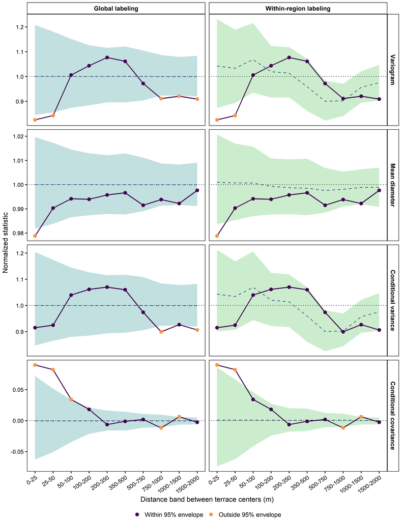

```r
# 32. Figure 6 plot
p6 <- mark_plot(fig6_df, DISPLAY_MAX_M)
print(p6)
```

```r
SAVED_FIGURES <- c(SAVED_FIGURES, save_figure(p6, "FIGURE_6", FIG_HEIGHT_MM[["FIGURE_6"]]))
```

**Fig. 6** Distance-band statistics under global and within-region random labeling over the 0 to 2 km test domain. Rows give the normalized variogram of log diameter, mean diameter of pairs, and conditional variance and covariance of log diameter, so the variogram equals variance minus covariance. Shaded areas are 95% global envelopes and dashed lines simulation means; orange points fall outside

#### Figure 6. Numerical description

```r
# 34. Figure 6 report
report_start("Figure 6", "Distance-dependent similarity of terrace diameters",
             paste("rows variogram, mean diameter, conditional variance and covariance of log",
                   "diameter, columns global and within-region labeling, x distance band,",
                   "shaded 95 percent global envelope, dashed simulation mean"))
```

```
## REPORT=Figure 6; SHOWS=Distance-dependent similarity of terrace diameters
## ENCODING=rows variogram, mean diameter, conditional variance and covariance of log
##     diameter, columns global and within-region labeling, x distance band, shaded 95
##     percent global envelope, dashed simulation mean
```

```r
bt <- band_text(pair_main$meta)
emit_rows(BANDS_M = vector_text(bt), PAIRS = vector_text(pair_main$meta$Pairs),
          TERRACES = vector_text(pair_main$meta$Terraces))
```

```
## BANDS_M=0-25, 25-50, 50-100, 100-200, 200-350, 350-500, 500-750, 750-1000, 1000-1500,
##     1500-2000
##     PAIRS=2054, 3301, 8150, 19642, 34939, 39310, 78989, 92028, 244822, 292184
##     TERRACES=1757, 2085, 2347, 2454, 2500, 2481, 2497, 2517, 2526, 2526
```

```r
for (res in list(list(r = mark_global, l = "Global labeling"),
                 list(r = mark_regional, l = "Within-region labeling"))) {
  K <- res$r$K
  a <- res$r$curves
  b <- res$r$decomposition
  emit_rows(NULL_MODEL = res$l, P_VARIOGRAM_AND_MEAN = fmt_p(a$P_global[1]),
            P_VARIANCE_AND_COVARIANCE = fmt_p(b$P_global[1]), PERMUTATIONS = a$B[1])
  emit_rows(VARIOGRAM = vector_text(a$Observed[seq_len(K)], 3))
  emit_rows(VARIOGRAM_LOW = vector_text(a$Low[seq_len(K)], 3),
            VARIOGRAM_HIGH = vector_text(a$High[seq_len(K)], 3))
  emit_rows(MEAN_DIAMETER = vector_text(a$Observed[K + seq_len(K)], 4))
  emit_rows(VARIANCE = vector_text(b$Observed[seq_len(K)], 3))
  emit_rows(COVARIANCE = vector_text(b$Observed[K + seq_len(K)], 3))
  emit_rows(COVARIANCE_LOW = vector_text(b$Low[K + seq_len(K)], 3),
            COVARIANCE_HIGH = vector_text(b$High[K + seq_len(K)], 3))
  emit_rows(CORRELATION = vector_text(res$r$rho$Observed, 3))
  emit_text("RESULT", paste0(res$l, ", bands outside the envelope, variogram ",
                             bands_outside(bt, a$Outside[seq_len(K)]), ", covariance ",
                             bands_outside(bt, b$Outside[K + seq_len(K)]), ", variance ",
                             bands_outside(bt, b$Outside[seq_len(K)])))
}
```

```
## NULL_MODEL=Global labeling; P_VARIOGRAM_AND_MEAN=0.0004
##     P_VARIANCE_AND_COVARIANCE=0.0001; PERMUTATIONS=10000
## VARIOGRAM=0.825, 0.843, 1.01, 1.04, 1.08, 1.06, 0.972, 0.911, 0.921, 0.909
## VARIOGRAM_LOW=0.845, 0.856, 0.873, 0.884, 0.896, 0.896, 0.904, 0.923, 0.924, 0.919
##     VARIOGRAM_HIGH=1.21, 1.18, 1.15, 1.13, 1.12, 1.12, 1.1, 1.09, 1.08, 1.08
## MEAN_DIAMETER=0.9788, 0.9903, 0.9941, 0.994, 0.9958, 0.9966, 0.9915, 0.9938, 0.9922,
##     0.9976
## VARIANCE=0.915, 0.925, 1.04, 1.06, 1.07, 1.06, 0.974, 0.899, 0.927, 0.907
## COVARIANCE=0.0897, 0.0822, 0.0341, 0.0181, -0.00637, -0.00116, 0.0019, -0.0118,
##     0.00626, -0.00262
## COVARIANCE_LOW=-0.0627, -0.0509, -0.0346, -0.0213, -0.0161, -0.016, -0.0115, -0.0106,
##     -0.00652, -0.00611
##     COVARIANCE_HIGH=0.0719, 0.0516, 0.0338, 0.0209, 0.0162, 0.0143, 0.0106, 0.00964,
##     0.00561, 0.00495
## CORRELATION=0.0981, 0.0889, 0.0328, 0.0171, -0.00595, -0.00109, 0.00195, -0.0131,
##     0.00675, -0.00289
## RESULT=Global labeling, bands outside the envelope, variogram 0-25, 25-50, 750-1000,
##     1000-1500, 1500-2000, covariance 0-25, 25-50, 50-100, 750-1000, 1000-1500, variance
##     750-1000, 1500-2000
## NULL_MODEL=Within-region labeling; P_VARIOGRAM_AND_MEAN=0.0001
##     P_VARIANCE_AND_COVARIANCE=0.0007; PERMUTATIONS=10000
## VARIOGRAM=0.825, 0.843, 1.01, 1.04, 1.08, 1.06, 0.972, 0.911, 0.921, 0.909
## VARIOGRAM_LOW=0.874, 0.894, 0.935, 0.915, 0.916, 0.861, 0.822, 0.841, 0.894, 0.903
##     VARIOGRAM_HIGH=1.23, 1.19, 1.22, 1.12, 1.12, 1.07, 0.984, 0.971, 1.02, 1.05
## MEAN_DIAMETER=0.9788, 0.9903, 0.9941, 0.994, 0.9958, 0.9966, 0.9915, 0.9938, 0.9922,
##     0.9976
## VARIANCE=0.915, 0.925, 1.04, 1.06, 1.07, 1.06, 0.974, 0.899, 0.927, 0.907
## COVARIANCE=0.0897, 0.0822, 0.0341, 0.0181, -0.00637, -0.00116, 0.0019, -0.0118,
##     0.00626, -0.00262
## COVARIANCE_LOW=-0.074, -0.0623, -0.0415, -0.0241, -0.018, -0.0169, -0.0106, -0.0102,
##     -0.00634, -0.00597
##     COVARIANCE_HIGH=0.0858, 0.0664, 0.0458, 0.0272, 0.02, 0.0194, 0.0125, 0.011,
##     0.00607, 0.00486
## CORRELATION=0.0981, 0.0889, 0.0328, 0.0171, -0.00595, -0.00109, 0.00195, -0.0131,
##     0.00675, -0.00289
## RESULT=Within-region labeling, bands outside the envelope, variogram 0-25, 25-50,
##     covariance 0-25, 25-50, 750-1000, 1000-1500, variance none
```

```r
emit_rows(GEOMETRIC_MEAN_SHIFT_PERCENT = vector_text(100 * expm1(mark_global$log_mean$Observed -
                                                                   mark_global$log_mean$Null), 3))
```

```
## GEOMETRIC_MEAN_SHIFT_PERCENT=-1.75, -0.742, -0.758, -0.775, -0.643, -0.5, -0.723,
##     -0.284, -0.517, 0.0946
```

```r
em <- mark_global$equal_marks
emit_rows(CLOSE_DOMAIN = em$Domain, PAIRS = em$Pairs, IDENTICAL_DIAMETERS = em$Identical,
          EXPECTED = em$Expected, P_UPPER = fmt_p(em$P_upper))
```

```
## CLOSE_DOMAIN=0-1 m; PAIRS=4; IDENTICAL_DIAMETERS=4; EXPECTED=0.5561; P_UPPER=0.0006
## CLOSE_DOMAIN=0-2 m; PAIRS=30; IDENTICAL_DIAMETERS=12; EXPECTED=4.176; P_UPPER=0.0009
## CLOSE_DOMAIN=2-5 m; PAIRS=109; IDENTICAL_DIAMETERS=16; EXPECTED=15.29; P_UPPER=0.46
```

```r
emit_rows(MAX_IDENTITY_ERROR = formatC(max(mark_global$identity_error,
                                           mark_regional$identity_error),
                                       format = "e", digits = 2),
          OVERLAPPING_PAIRS = mark_global$overlap$Observed,
          OVERLAP_NULL_95 = interval_text(mark_global$overlap$Null_low,
                                          mark_global$overlap$Null_high),
          P_OVERLAP = fmt_p(mark_global$overlap$P))
```

```
## MAX_IDENTITY_ERROR=9.63e-11; OVERLAPPING_PAIRS=478; OVERLAP_NULL_95=472 to 511
##     P_OVERLAP=0.23
```

```r
emit_text("RESULT", paste0("Correlation of neighboring log diameters ",
                           fmt_num(mark_global$rho$Observed[1], 3), " at ", bt[1], " m and ",
                           fmt_num(mark_global$rho$Observed[2], 3), " at ", bt[2], " m"))
```

```
## RESULT=Correlation of neighboring log diameters 0.0981 at 0-25 m and 0.0889 at 25-50 m
```

```r
emit_text("NOTE", paste("The joint variogram and mean test over 0 to 2 km is the primary global",
                        "test; variance, covariance and correlation are follow-up statistics on",
                        "the same permutations"))
```

```
## NOTE=The joint variogram and mean test over 0 to 2 km is the primary global test,
##     variance, covariance and correlation are follow-up statistics on the same
##     permutations
```

```r
emit_rows(PRODUCT_MARK_P_GLOBAL = fmt_p(mark_global$product$P_global[1]),
          PRODUCT_MARK_P_REGIONAL = fmt_p(mark_regional$product$P_global[1]))
```

```
## PRODUCT_MARK_P_GLOBAL=0.012; PRODUCT_MARK_P_REGIONAL=0.0044
```

```r
emit_text("NOTE", "The figure shows every distance band of the 0 to 2 km test domain")
```

```
## NOTE=The figure shows every distance band of the 0 to 2 km test domain
```

## Figure 7. Terrace diameter, local concentration and residual dependence

```r
# 36. Figure 7 regression
x <- log1p(primary$Concentration)
y <- log(D)
if (stats::sd(x) == 0) stop("Concentration has no variation")
model0 <- stats::lm(y ~ 1)
model1 <- stats::lm(y ~ x)
fstat <- summary(model1)$fstatistic
ols <- data.frame(Intercept = unname(stats::coef(model1)[1]), Slope = unname(stats::coef(model1)[2]),
                  F = unname(fstat[["value"]]), DF1 = unname(fstat[["numdf"]]),
                  DF2 = unname(fstat[["dendf"]]),
                  P = stats::pf(fstat[["value"]], fstat[["numdf"]], fstat[["dendf"]],
                                lower.tail = FALSE),
                  R2 = summary(model1)$r.squared)
block_ids <- function(width, offset = c(0, 0)) {
  interaction(floor((xy_local[, 1] + offset[1]) / width),
              floor((xy_local[, 2] + offset[2]) / width), drop = TRUE)
}
boot_step <- function(k, p) {
  chosen <- sample.int(length(p$blocks), length(p$blocks), replace = TRUE)
  ii <- unlist(p$blocks[chosen], use.names = FALSE)
  f <- stats::lm.fit(cbind(1, p$x[ii]), p$y[ii])
  b <- f$coefficients[2]
  if (!is.finite(b)) return(c(0, 0, 0, 0))
  c(1, f$coefficients[1], b, 100 * expm1(b * p$dx))
}
boot_model <- function(keep, radius, width, B, seed, offset = c(0, 0)) {
  xx <- log1p(conc[[as.character(radius)]]$Concentration[keep])
  yy <- y[keep]
  dx <- diff(qv(xx, c(.25, .75)))
  blocks <- split(seq_along(keep), droplevels(block_ids(width, offset)[keep]))
  f <- stats::lm.fit(cbind(1, xx), yy)
  if (length(blocks) < 3L || !all(is.finite(f$coefficients))) {
    stop("Insufficient variation for the block bootstrap")
  }
  z <- mc_run(B, boot_step, list(blocks = blocks, x = xx, y = yy, dx = dx), seed,
              paste0("Block bootstrap, radius ", radius, " m, block ", width, " m"))
  good <- z[, 1] == 1
  if (mean(good) < 0.99) stop("More than 1 percent of bootstrap fits are singular")
  z <- z[good, , drop = FALSE]
  beta <- unname(f$coefficients[2])
  list(summary = data.frame(Radius_m = radius, Block_m = width, Blocks = length(blocks),
                            Beta = beta, Beta_low = qv(z[, 3], .025), Beta_high = qv(z[, 3], .975),
                            Effect = 100 * expm1(beta * dx), Effect_low = qv(z[, 4], .025),
                            Effect_high = qv(z[, 4], .975)),
       draws = z, dx = dx)
}
boot_main <- boot_model(seq_len(n), PRIMARY_RADIUS_M, BOOT_BLOCK_M, N_BOOT, SEED + 400000L)
slope_step <- function(k, p) {
  yy <- p$y
  for (g in p$groups) yy[g] <- p$y[g[sample.int(length(g))]]
  sum((p$x - mean(p$x)) * (yy - mean(yy))) / sum((p$x - mean(p$x))^2)
}
slope_global <- mc_run(N_PERM, slope_step, list(x = x, y = y, groups = list(seq_len(n))),
                       SEED + 500000L, "Slope, global labeling")
slope_regional <- mc_run(N_PERM, slope_step, list(x = x, y = y, groups = split(seq_len(n), regions)),
                         SEED + 600000L, "Slope, within-region labeling")
slope_p <- c(Global = mc_p(ols$Slope, slope_global), Regional = mc_p(ols$Slope, slope_regional))
effect_log <- boot_main$draws[, 3] * boot_main$dx
contrast <- data.frame(Log_SD = stats::sd(y),
                       Standardized = ols$Slope * boot_main$dx / stats::sd(y),
                       Standardized_low = qv(effect_log / stats::sd(y), .025),
                       Standardized_high = qv(effect_log / stats::sd(y), .975),
                       Difference_m = 10 * expm1(ols$Slope * boot_main$dx),
                       Difference_low = qv(10 * expm1(effect_log), .025),
                       Difference_high = qv(10 * expm1(effect_log), .975))
xg <- seq(min(x), max(x), length.out = 120)
pred_draws <- exp(outer(boot_main$draws[, 3], xg, "*") + boot_main$draws[, 2])
fit_grid <- data.frame(C = expm1(xg), Fit = exp(ols$Intercept + ols$Slope * xg),
                       Low = apply(pred_draws, 2, stats::quantile, .025),
                       High = apply(pred_draws, 2, stats::quantile, .975))
z_std <- stats::rstandard(model1)
lag_matrix <- DM <= LAG_RADIUS_M
lag_n <- rowSums(lag_matrix)
lag_mean <- ifelse(lag_n > 0, as.numeric(lag_matrix %*% z_std) / pmax(lag_n, 1L), NA_real_)
rm(lag_matrix)
lag_cor <- stats::cor(z_std, lag_mean, use = "complete.obs")
```

```r
# 37. Figure 7 validation
set.seed(SEED + 700000L)
cv_block <- stats::kmeans(xy_local, centers = CV_BLOCKS, nstart = 25, iter.max = 200)$cluster
make_partitions <- function() {
  out <- list()
  keys <- character()
  attempt <- 0L
  while (length(out) < CV_REPEATS && attempt < 1000L) {
    attempt <- attempt + 1L
    set.seed(SEED + 710000L + attempt)
    fd <- sample(rep(seq_len(CV_FOLDS), length.out = CV_BLOCKS))[cv_block]
    key <- paste(match(fd, unique(fd)), collapse = ",")
    if (!key %in% keys) {
      out[[length(out) + 1L]] <- fd
      keys <- c(keys, key)
    }
  }
  if (length(out) != CV_REPEATS) stop("Distinct spatial partitions could not be built")
  out
}
partitions <- make_partitions()
cv_step <- function(k, p) {
  fd <- p$folds[[k]]
  out <- matrix(NA_real_, length(fd), 2L)
  min_sep <- Inf
  for (f in seq_len(p$K)) {
    te <- which(fd == f)
    tr0 <- which(fd != f)
    tr <- tr0[apply(p$dist[tr0, te, drop = FALSE], 1, min) >= p$buffer]
    if (length(tr) < 30L || length(te) < 1L) stop("Insufficient fold after buffering")
    for (j in 1:2) {
      M <- if (j == 1L) p$Z0 else p$Z1
      m <- stats::lm.fit(M[tr, , drop = FALSE], p$y[tr])
      if (any(!is.finite(m$coefficients))) stop("Singular cross-validation fit")
      out[te, j] <- exp(M[te, , drop = FALSE] %*% m$coefficients + stats::median(m$residuals))
    }
    min_sep <- min(min_sep, min(p$dist[tr, te, drop = FALSE]))
  }
  if (any(!is.finite(out))) stop("Incomplete held-out predictions")
  mae <- colMeans(abs(exp(p$y) - out))
  c(mae, mae[1] - mae[2], min_sep)
}
run_cv <- function(Z0, Z1, seed, label) {
  mc_run(CV_REPEATS, cv_step, list(folds = partitions, K = CV_FOLDS, Z0 = Z0, Z1 = Z1, y = y,
                                   dist = DM, buffer = CV_BUFFER_M), seed, label)
}
cv_conc <- run_cv(matrix(1, n, 1), cbind(1, x), SEED + 720000L,
                  "Cross-validation, concentration")
resid_stat <- function(z, pair) {
  v <- stats::var(z)
  as.numeric(rowsum(pair$w * (z[pair$i] - z[pair$j])^2 / (2 * v), pair$b, reorder = FALSE)) /
    pair$den
}
environment(resid_stat) <- baseenv()
resid_near_stat <- function(z, pair) {
  sum(pair$near_w * (z[pair$near_i] - z[pair$near_j])^2) / (2 * stats::var(z) * sum(pair$near_w))
}
environment(resid_near_stat) <- baseenv()
signflip_step <- function(k, p) {
  ys <- p$fitted + p$adjusted * sample(c(-1, 1), length(p$adjusted), replace = TRUE)
  f <- stats::lm.fit(p$X, ys)
  c(p$stat(f$residuals, p$pair), p$near(f$residuals, p$pair))
}
run_residual <- function(model, label, seed) {
  r <- stats::residuals(model)
  adjusted <- r / sqrt(pmax(1 - stats::hatvalues(model), 1e-6))
  sims <- mc_run(N_SIM, signflip_step, list(fitted = stats::fitted(model), adjusted = adjusted,
                                            X = stats::model.matrix(model), stat = resid_stat,
                                            near = resid_near_stat, pair = pair_main),
                 seed, paste("Sign-flip residual resampling,", label))
  K <- nrow(pair_main$meta)
  curve <- make_envelope(resid_stat(r, pair_main), sims[, seq_len(K), drop = FALSE],
                         pair_main$meta$Midpoint_m, label)
  curve$Band <- seq_len(K)
  curve$Upper_m <- pair_main$meta$Upper_m
  curve$Model <- label
  near_obs <- resid_near_stat(r, pair_main)
  near_sim <- sims[, K + 1L]
  list(curve = curve,
       near = data.frame(Model = label, Ratio = near_obs / mean(near_sim),
                         Null_low = qv(near_sim, .025) / mean(near_sim),
                         Null_high = qv(near_sim, .975) / mean(near_sim),
                         P = mc_p(near_obs, near_sim), P_global = curve$P_global[1],
                         R2 = summary(model)$r.squared))
}
res_m1 <- run_residual(model1, "M1 concentration", SEED + 800000L)
res_m2 <- NULL
res_m3 <- NULL
terrain_coef <- NULL
cv_terrain <- NULL
if (USE_DEM_MARKS) {
  tdat <- data.frame(y = y, x = x, terrain_at)
  model2 <- stats::lm(y ~ elev + slope + tpi, data = tdat)
  model3 <- stats::lm(y ~ x + elev + slope + tpi, data = tdat)
  res_m2 <- run_residual(model2, "M2 terrain", SEED + 2700000L)
  res_m3 <- run_residual(model3, "M3 concentration and terrain", SEED + 2300000L)
  boot_lm_step <- function(k, p) {
    chosen <- sample.int(length(p$blocks), length(p$blocks), replace = TRUE)
    ii <- unlist(p$blocks[chosen], use.names = FALSE)
    b <- stats::lm.fit(p$X[ii, , drop = FALSE], p$y[ii])$coefficients
    if (any(!is.finite(b))) return(c(0, rep(0, ncol(p$X))))
    c(1, b)
  }
  boot_coef <- function(model, label, seed) {
    X <- stats::model.matrix(model)
    blocks <- split(seq_len(n), droplevels(block_ids(BOOT_BLOCK_M)))
    z <- mc_run(N_SENS, boot_lm_step, list(blocks = blocks, X = X, y = y), seed,
                paste("Block bootstrap coefficients,", label))
    z <- z[z[, 1] == 1, -1, drop = FALSE]
    data.frame(Model = label, Term = colnames(X), Estimate = unname(stats::coef(model)),
               Low = apply(z, 2, stats::quantile, .025),
               High = apply(z, 2, stats::quantile, .975))
  }
  terrain_coef <- rbind(boot_coef(model2, "M2 terrain", SEED + 2750000L),
                        boot_coef(model3, "M3 concentration and terrain", SEED + 2760000L))
  Zt <- cbind(1, as.matrix(terrain_at))
  cv_terrain <- run_cv(Zt, cbind(Zt, x), SEED + 2400000L, "Cross-validation, terrain")
}
residual_models <- Filter(Negate(is.null), list(res_m1, res_m2, res_m3))
```

```r
# 38. Figure 7 diagnostics
pearson_r <- stats::cor(x, y)
spearman_rs <- stats::cor(x, y, method = "spearman")
rank_step <- function(k, p) {
  chosen <- sample.int(length(p$blocks), length(p$blocks), replace = TRUE)
  ii <- unlist(p$blocks[chosen], use.names = FALSE)
  stats::cor(p$x[ii], p$y[ii], method = "spearman")
}
rank_boot <- mc_run(N_SENS, rank_step,
                    list(blocks = split(seq_len(n), droplevels(block_ids(BOOT_BLOCK_M))),
                         x = x, y = y),
                    SEED + 2800000L, "Block bootstrap, Spearman correlation")
cooks <- stats::cooks.distance(model1)
keep_trim <- which(abs(z_std) <= 3)
trim_model <- boot_model(keep_trim, PRIMARY_RADIUS_M, BOOT_BLOCK_M, N_SENS, SEED + 2810000L)
spline_basis <- splines::ns(x, df = 3)
model_spline <- stats::lm(y ~ spline_basis)
x_central <- seq(qv(x, .05), qv(x, .95), length.out = 100)
pred_linear <- ols$Intercept + ols$Slope * x_central
pred_spline <- as.numeric(cbind(1, stats::predict(spline_basis, x_central)) %*%
                            stats::coef(model_spline))
spline_test <- stats::anova(model1, model_spline)
curvature <- data.frame(Delta_AIC = stats::AIC(model_spline) - stats::AIC(model1),
                        Max_difference_pct = 100 * max(abs(expm1(pred_spline - pred_linear))),
                        P = spline_test[["Pr(>F)"]][2])
concentration_quartile <- cut(x, breaks = unique(qv(x, c(0, .25, .5, .75, 1))),
                              include.lowest = TRUE, labels = FALSE)
residual_sd_quartile <- as.numeric(tapply(stats::residuals(model1), concentration_quartile,
                                          stats::sd))
vif <- NULL
if (USE_DEM_MARKS) {
  vif_data <- data.frame(x = x, terrain_at)
  vif <- vapply(names(vif_data), function(v) {
    f <- stats::reformulate(setdiff(names(vif_data), v), response = v)
    1 / (1 - summary(stats::lm(f, data = vif_data))$r.squared)
  }, numeric(1))
}
```

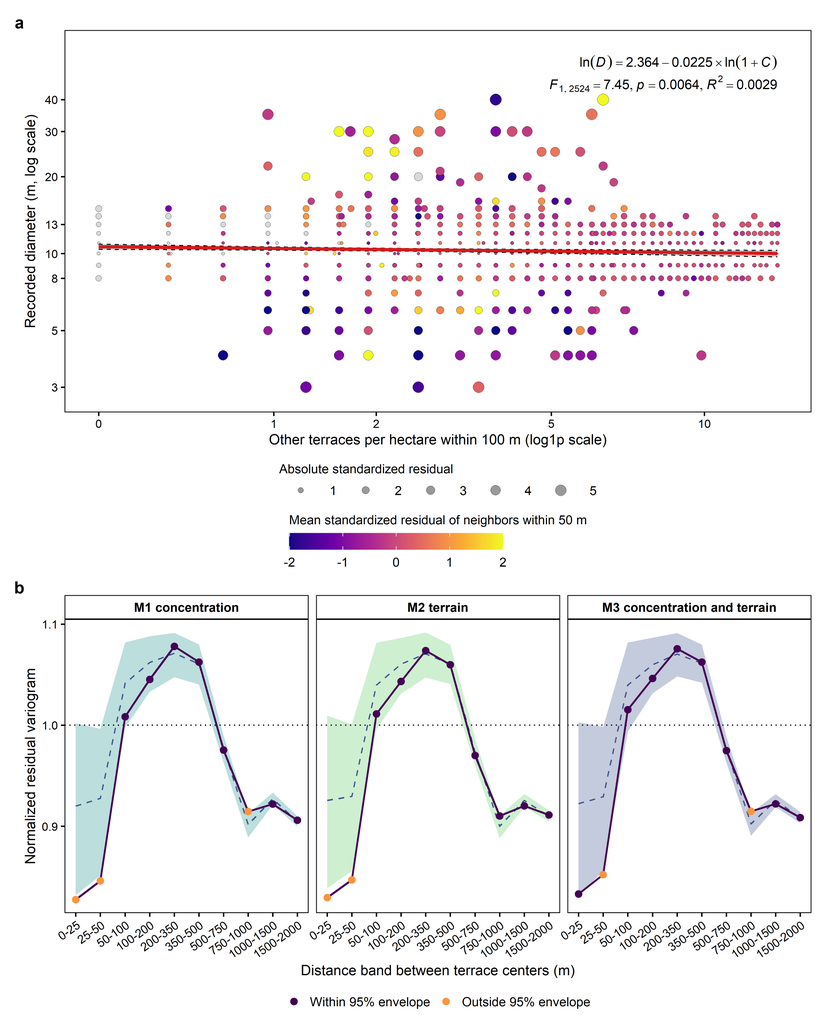

```r
# 39. Figure 7 plot
fig7a_df <- data.frame(C = primary$Concentration, D = D, Size = abs(z_std), Lag = lag_mean)
fig7a_df <- fig7a_df[order(fig7a_df$Size), ]
lab_eq <- sprintf('ln(italic(D)) == "%.3f" %s "%.4f" %%*%% ln(1 + italic(C))', ols$Intercept,
                  if (ols$Slope < 0) "-" else "+", abs(ols$Slope))
lab_p <- if (ols$P < 0.001) 'italic(p) < "0.001"' else sprintf('italic(p) == "%.4f"', ols$P)
lab_stat <- sprintf('list(italic(F)[list(%d, %d)] == "%.2f", %s, italic(R)^2 == "%.4f")',
                    as.integer(ols$DF1), as.integer(ols$DF2), ols$F, lab_p, ols$R2)
p7a <- ggplot() +
  geom_ribbon(data = fit_grid, aes(x = C, ymin = Low, ymax = High), fill = "grey80") +
  geom_point(data = fig7a_df, aes(C, D, size = Size, fill = Lag), shape = 21, colour = "black",
             stroke = 0.12) +
  geom_line(data = fit_grid, aes(C, Low), colour = "black", linewidth = 0.3, linetype = "dashed") +
  geom_line(data = fit_grid, aes(C, High), colour = "black", linewidth = 0.3, linetype = "dashed") +
  geom_line(data = fit_grid, aes(C, Fit), colour = COL[["fit"]], linewidth = 0.9) +
  annotate("text", x = max(fig7a_df$C), y = c(56, 46), label = c(lab_eq, lab_stat), parse = TRUE,
           hjust = 1, size = 2.8, colour = "black") +
  scale_x_continuous(transform = "log1p", breaks = c(0, 1, 2, 5, 10)) +
  scale_y_log10(breaks = c(3, 5, 8, 10, 13, 20, 30, 40), limits = c(2.8, 64)) +
  scale_size(range = c(0.3, 3.2), name = "Absolute standardized residual") +
  scale_fill_viridis_c(option = "plasma", limits = c(-2, 2), oob = scales::squish,
                       na.value = "grey85",
                       name = "Mean standardized residual of neighbors within 50 m") +
  guides(size = guide_legend(override.aes = list(fill = "grey60"))) +
  labs(x = "Other terraces per hectare within 100 m (log1p scale)",
       y = "Recorded diameter (m, log scale)") +
  theme_v7() +
  theme(legend.key.width = grid::unit(9, "mm"))
res_df <- do.call(rbind, lapply(residual_models, function(m) m$curve))
res_df <- res_df[res_df$Upper_m <= DISPLAY_MAX_M, ]
res_df$Model <- factor(res_df$Model, levels = unique(res_df$Model))
res_meta <- pair_main$meta[pair_main$meta$Upper_m <= DISPLAY_MAX_M, ]
res_fill <- setNames(tint(c(COL[["global"]], COL[["regional"]], COL[["reference"]]), 0.7),
                     c("M1 concentration", "M2 terrain", "M3 concentration and terrain"))
p7b <- ggplot(res_df, aes(Band, Observed)) +
  geom_ribbon(aes(ymin = Low, ymax = High, fill = Model)) +
  geom_hline(yintercept = 1, linetype = "dotted", colour = COL[["neutral"]], linewidth = 0.35) +
  geom_line(aes(y = Reference), colour = COL[["reference"]], linetype = "dashed",
            linewidth = 0.4) +
  geom_line(colour = COL[["observed"]], linewidth = 0.6) +
  geom_point(aes(colour = Outside), size = 1.7) +
  facet_wrap(~ Model, nrow = 1) +
  scale_x_continuous(breaks = seq_len(nrow(res_meta)), labels = band_text(res_meta)) +
  scale_fill_manual(values = res_fill, guide = "none") +
  scale_colour_manual(values = c("FALSE" = COL[["observed"]], "TRUE" = COL[["outside"]]),
                      labels = c("FALSE" = "Within 95% envelope", "TRUE" = "Outside 95% envelope"),
                      name = NULL) +
  labs(x = "Distance band between terrace centers (m)", y = "Normalized residual variogram") +
  theme_v7() +
  theme(axis.text.x = element_text(angle = 35, hjust = 1))
p7 <- (p7a / p7b) + plot_layout(heights = c(1.3, 1)) + plot_annotation(tag_levels = "a")
print(p7)
```

```r
SAVED_FIGURES <- c(SAVED_FIGURES, save_figure(p7, "FIGURE_7", FIG_HEIGHT_MM[["FIGURE_7"]]))
```

**Fig. 7** (a) Recorded diameter and other terraces per hectare within 100 m. Red line, least-squares fit of log diameter on log(1 + concentration); grey band, 95% spatial block-bootstrap interval; point size, absolute standardized residual; color, mean standardized residual of neighbors within 50 m. (b) Residual variograms over 0 to 2 km with 95% global envelopes from sign-flip residual resampling

#### Figure 7. Numerical description

```r
# 41. Figure 7 report
report_start("Figure 7", "Terrace diameter, local concentration and residual dependence",
             paste("panel a points terraces, size absolute standardized residual, fill mean",
                   "standardized residual of neighbors within 50 m, red line least-squares fit,",
                   "grey band 95 percent block-bootstrap interval, panel b residual variograms",
                   "with 95 percent sign-flip envelopes"))
```

```
## REPORT=Figure 7; SHOWS=Terrace diameter, local concentration and residual dependence
## ENCODING=panel a points terraces, size absolute standardized residual, fill mean
##     standardized residual of neighbors within 50 m, red line least-squares fit, grey
##     band 95 percent block-bootstrap interval, panel b residual variograms with 95
##     percent sign-flip envelopes
```

```r
emit_rows(RADIUS_M = conc_audit$Radius_m, MEDIAN_NEIGHBORS = conc_audit$Median_count,
          CONCENTRATION_P25_P75_PER_HA = interval_text(conc_audit$P25, conc_audit$P75, 3))
```

```
## RADIUS_M=50; MEDIAN_NEIGHBORS=3; CONCENTRATION_P25_P75_PER_HA=2.55 to 7.64
## RADIUS_M=100; MEDIAN_NEIGHBORS=9; CONCENTRATION_P25_P75_PER_HA=1.59 to 4.46
## RADIUS_M=200; MEDIAN_NEIGHBORS=23; CONCENTRATION_P25_P75_PER_HA=1.03 to 2.94
## RADIUS_M=500; MEDIAN_NEIGHBORS=73; CONCENTRATION_P25_P75_PER_HA=0.662 to 1.6
## RADIUS_M=1000; MEDIAN_NEIGHBORS=221; CONCENTRATION_P25_P75_PER_HA=0.545 to 0.949
```

```r
emit_rows(INTERCEPT = ols$Intercept, SLOPE = ols$Slope, F = ols$F,
          DF = paste0(ols$DF1, ",", ols$DF2), P_OLS = fmt_p(ols$P), R2 = ols$R2,
          AIC_M0 = stats::AIC(model0), AIC_M1 = stats::AIC(model1))
```

```
## INTERCEPT=2.364; SLOPE=-0.0225; F=7.453; DF=1,2524; P_OLS=0.0064; R2=0.002944
##     AIC_M0=54.33; AIC_M1=48.88
```

```r
emit_rows(SLOPE_95_BLOCK = interval_text(boot_main$summary$Beta_low, boot_main$summary$Beta_high),
          P_PERMUTATION_GLOBAL = fmt_p(slope_p[["Global"]]),
          P_PERMUTATION_REGIONAL = fmt_p(slope_p[["Regional"]]),
          BLOCKS = boot_main$summary$Blocks)
```

```
## SLOPE_95_BLOCK=-0.03945 to -0.00558; P_PERMUTATION_GLOBAL=0.0062
##     P_PERMUTATION_REGIONAL=0.018; BLOCKS=155
```

```r
emit_rows(CONTRAST_PERCENT = boot_main$summary$Effect,
          CONTRAST_95 = interval_text(boot_main$summary$Effect_low, boot_main$summary$Effect_high, 3),
          STANDARDIZED_SD = contrast$Standardized,
          STANDARDIZED_95 = interval_text(contrast$Standardized_low, contrast$Standardized_high, 3),
          DIFFERENCE_AT_10_M = contrast$Difference_m,
          DIFFERENCE_95_M = interval_text(contrast$Difference_low, contrast$Difference_high, 3))
```

```
## CONTRAST_PERCENT=-1.662; CONTRAST_95=-2.89 to -0.415; STANDARDIZED_SD=-0.06854
##     STANDARDIZED_95=-0.12 to -0.017; DIFFERENCE_AT_10_M=-0.1662
##     DIFFERENCE_95_M=-0.289 to -0.0415
```

```r
emit_rows(CV_MAE_GAIN_MM = 1000 * mean(cv_conc[, 3]),
          CV_RANGE_MM = interval_text(1000 * min(cv_conc[, 3]), 1000 * max(cv_conc[, 3]), 3),
          CV_PARTITIONS_FAVORING_CONCENTRATION = paste(sum(cv_conc[, 3] > 0), "of", CV_REPEATS),
          CV_MIN_SEPARATION_M = min(cv_conc[, 4]))
```

```
## CV_MAE_GAIN_MM=0.8647; CV_RANGE_MM=-2.27 to 8.67
##     CV_PARTITIONS_FAVORING_CONCENTRATION=3 of 10; CV_MIN_SEPARATION_M=250.1
```

```r
emit_rows(ABS_STANDARDIZED_RESIDUAL_ABOVE_2 = sum(abs(z_std) > 2),
          ABOVE_3 = sum(abs(z_std) > 3), MAX_ABS_STANDARDIZED_RESIDUAL = max(abs(z_std)))
```

```
## ABS_STANDARDIZED_RESIDUAL_ABOVE_2=113; ABOVE_3=45; MAX_ABS_STANDARDIZED_RESIDUAL=5.614
```

```r
emit_rows(LAG_RADIUS_M = LAG_RADIUS_M, TERRACES_WITH_NEIGHBORS = sum(lag_n > 0),
          RESIDUAL_LAG_CORRELATION = lag_cor)
```

```
## LAG_RADIUS_M=50; TERRACES_WITH_NEIGHBORS=2281; RESIDUAL_LAG_CORRELATION=0.1796
```

```r
res_table <- do.call(rbind, lapply(residual_models, function(m) m$near))
emit_rows(MODEL = res_table$Model, R2 = res_table$R2, P_GLOBAL = fmt_p(res_table$P_global),
          NEAR_RATIO = res_table$Ratio,
          NEAR_NULL_95 = interval_text(res_table$Null_low, res_table$Null_high, 3),
          P_NEAR = fmt_p(res_table$P))
```

```
## MODEL=M1 concentration; R2=0.002944; P_GLOBAL=0.0098; NEAR_RATIO=0.9071
##     NEAR_NULL_95=0.954 to 1.04; P_NEAR=0.0002
## MODEL=M2 terrain; R2=0.003973; P_GLOBAL=0.017; NEAR_RATIO=0.9054
##     NEAR_NULL_95=0.956 to 1.04; P_NEAR=0.0002
## MODEL=M3 concentration and terrain; R2=0.008247; P_GLOBAL=0.011; NEAR_RATIO=0.9117
##     NEAR_NULL_95=0.955 to 1.04; P_NEAR=0.0002
```

```r
if (USE_DEM_MARKS) {
  emit_rows(TERRAIN_MODEL = terrain_coef$Model, TERM = terrain_coef$Term,
            ESTIMATE = terrain_coef$Estimate,
            BLOCK_95 = interval_text(terrain_coef$Low, terrain_coef$High, 3))
  emit_rows(CV_MAE_TERRAIN_M = mean(cv_terrain[, 1]),
            CV_MAE_TERRAIN_CONCENTRATION_M = mean(cv_terrain[, 2]),
            CV_GAIN_OF_CONCENTRATION_MM = 1000 * mean(cv_terrain[, 3]))
}
```

```
## TERRAIN_MODEL=M2 terrain; TERM=(Intercept); ESTIMATE=2.334; BLOCK_95=2.32 to 2.35
## TERRAIN_MODEL=M2 terrain; TERM=elev; ESTIMATE=0.002821; BLOCK_95=-0.0087 to 0.0149
## TERRAIN_MODEL=M2 terrain; TERM=slope; ESTIMATE=-0.01581; BLOCK_95=-0.0298 to -0.00267
## TERRAIN_MODEL=M2 terrain; TERM=tpi; ESTIMATE=-0.00541; BLOCK_95=-0.0158 to 0.00451
## TERRAIN_MODEL=M3 concentration and terrain; TERM=(Intercept); ESTIMATE=2.371
##     BLOCK_95=2.35 to 2.39
## TERRAIN_MODEL=M3 concentration and terrain; TERM=x; ESTIMATE=-0.0277
##     BLOCK_95=-0.0442 to -0.00865
## TERRAIN_MODEL=M3 concentration and terrain; TERM=elev; ESTIMATE=0.00516
##     BLOCK_95=-0.0064 to 0.0168
## TERRAIN_MODEL=M3 concentration and terrain; TERM=slope; ESTIMATE=-0.01826
##     BLOCK_95=-0.0309 to -0.00562
## TERRAIN_MODEL=M3 concentration and terrain; TERM=tpi; ESTIMATE=-0.007338
##     BLOCK_95=-0.0176 to 0.00272
## CV_MAE_TERRAIN_M=1.97; CV_MAE_TERRAIN_CONCENTRATION_M=1.965
##     CV_GAIN_OF_CONCENTRATION_MM=4.197
```

```r
emit_rows(PEARSON_R = pearson_r, SPEARMAN_RS = spearman_rs,
          SPEARMAN_95_BLOCK = interval_text(qv(rank_boot[, 1], .025), qv(rank_boot[, 1], .975), 3))
```

```
## PEARSON_R=-0.05426; SPEARMAN_RS=-0.05911; SPEARMAN_95_BLOCK=-0.1 to -0.0207
```

```r
emit_rows(MAX_COOK_DISTANCE = max(cooks), COOK_ABOVE_4_OVER_N = sum(cooks > 4 / n),
          N_WITHOUT_ABS_Z_ABOVE_3 = length(keep_trim), SLOPE_WITHOUT = trim_model$summary$Beta,
          SLOPE_WITHOUT_95_BLOCK = interval_text(trim_model$summary$Beta_low,
                                                 trim_model$summary$Beta_high, 3),
          CONTRAST_WITHOUT_PERCENT = trim_model$summary$Effect)
```

```
## MAX_COOK_DISTANCE=0.01462; COOK_ABOVE_4_OVER_N=96; N_WITHOUT_ABS_Z_ABOVE_3=2481
##     SLOPE_WITHOUT=-0.02369; SLOPE_WITHOUT_95_BLOCK=-0.0359 to -0.0099
##     CONTRAST_WITHOUT_PERCENT=-1.748
```

```r
emit_rows(SPLINE_DF = 3, DELTA_AIC_SPLINE_MINUS_LINEAR = curvature$Delta_AIC,
          MAX_SPLINE_LINEAR_DIFFERENCE_PERCENT = curvature$Max_difference_pct,
          P_SPLINE_TERMS_OLS = fmt_p(curvature$P))
```

```
## SPLINE_DF=3; DELTA_AIC_SPLINE_MINUS_LINEAR=2.743
##     MAX_SPLINE_LINEAR_DIFFERENCE_PERCENT=0.7366; P_SPLINE_TERMS_OLS=0.53
```

```r
emit_rows(RESIDUAL_SD_BY_CONCENTRATION_QUARTILE = vector_text(residual_sd_quartile, 3))
```

```
## RESIDUAL_SD_BY_CONCENTRATION_QUARTILE=0.218, 0.267, 0.254, 0.24
```

```r
if (!is.null(vif)) emit_rows(VIF_TERM = names(vif), VIF = vif)
```

```
## VIF_TERM=x; VIF=1.043
## VIF_TERM=elev; VIF=1.063
## VIF_TERM=slope; VIF=1.103
## VIF_TERM=tpi; VIF=1.054
```

```r
emit_text("NOTE", paste("Regression diagnostics follow Drennan (2009), with outliers, curvature",
                        "and thickness of the point cloud checked and a rank correlation as a",
                        "robust alternative"))
```

```
## NOTE=Regression diagnostics follow Drennan (2009), with outliers, curvature and
##     thickness of the point cloud checked and a rank correlation as a robust alternative
```

```r
for (k in seq_len(nrow(res_table))) {
  emit_text("RESULT", paste0(res_table$Model[k], ", near-range residual variogram ratio ",
                             fmt_num(res_table$Ratio[k], 3), " against a null range of ",
                             interval_text(res_table$Null_low[k], res_table$Null_high[k], 3)))
}
```

```
## RESULT=M1 concentration, near-range residual variogram ratio 0.907 against a null range
##     of 0.954 to 1.04
## RESULT=M2 terrain, near-range residual variogram ratio 0.905 against a null range of
##     0.956 to 1.04
## RESULT=M3 concentration and terrain, near-range residual variogram ratio 0.912 against
##     a null range of 0.955 to 1.04
```

```r
emit_text("NOTE", paste("F and p are ordinary least-squares statistics and assume independent",
                        "terraces; block-bootstrap intervals account for spatial dependence, while",
                        "labeling permutations assume exchangeable diameters"))
```

```
## NOTE=F and p are ordinary least-squares statistics and assume independent terraces,
##     block-bootstrap intervals account for spatial dependence, while labeling
##     permutations assume exchangeable diameters
```

```r
emit_text("NOTE", paste("Sign-flip resampling keeps each residual magnitude and randomizes its",
                        "sign, so the residual variogram test addresses covariance between",
                        "neighbors"))
```

```
## NOTE=Sign-flip resampling keeps each residual magnitude and randomizes its sign, so the
##     residual variogram test addresses covariance between neighbors
```

## Figure 8. Robustness of short-range similarity

```r
# 43. Figure 8 compute
sc_specs <- list(
  list(label = "Alternative bands", keep = seq_len(n), breaks = MARK_BREAKS_ALT_M,
       correction = "none", lower = 0),
  list(label = "Border weighting", keep = seq_len(n), breaks = MARK_BREAKS_M,
       correction = "border", lower = 0),
  list(label = "Exclude pairs under 5 m", keep = seq_len(n), breaks = MARK_BREAKS_M,
       correction = "none", lower = 5),
  list(label = "Beyond maximum diameter", keep = seq_len(n), breaks = MARK_BREAKS_M,
       correction = "none", lower = max(D) + sqrt(.Machine$double.eps)),
  list(label = "Without upper 1 percent of diameters", keep = which(D <= qv(D, .99)),
       breaks = MARK_BREAKS_M, correction = "none", lower = 0))
for (g in seq_len(LOO_REGIONS)) {
  sc_specs[[length(sc_specs) + 1L]] <- list(label = paste("Omit region", g),
                                            keep = which(regions != g), breaks = MARK_BREAKS_M,
                                            correction = "none", lower = 0)
}
if (length(close_vertices)) {
  sc_specs[[length(sc_specs) + 1L]] <- list(label = "Exclude terraces in pairs under 2 m",
                                            keep = keep_no_close, breaks = MARK_BREAKS_M,
                                            correction = "none", lower = 0)
  sc_specs[[length(sc_specs) + 1L]] <- list(label = "One terrace per group under 2 m",
                                            keep = keep_one_close, breaks = MARK_BREAKS_M,
                                            correction = "none", lower = 0)
}
sens <- lapply(seq_along(sc_specs), function(k) {
  s <- sc_specs[[k]]
  r <- run_marks(make_pairs(s$keep, s$breaks, s$correction, s$lower), N_SENS,
                 SEED + 900000L + k * 10000L, s$label)
  list(near = near_effect(r, s$label), fixed = fixed_effect(r, s$label))
})
sens_near <- rbind(near_effect(mark_global, "Global labeling"),
                   near_effect(mark_regional, "Within-region labeling"),
                   do.call(rbind, lapply(sens, `[[`, "near")))
sens_fixed <- rbind(fixed_effect(mark_global, "Global labeling"),
                    fixed_effect(mark_regional, "Within-region labeling"),
                    do.call(rbind, lapply(sens, `[[`, "fixed")))
near_group <- c("Global labeling" = "Primary nulls", "Within-region labeling" = "Primary nulls",
                "Alternative bands" = "Bands and edges", "Border weighting" = "Bands and edges",
                "Exclude pairs under 5 m" = "Geometry", "Beyond maximum diameter" = "Geometry",
                "Without upper 1 percent of diameters" = "Influence",
                "Exclude terraces in pairs under 2 m" = "Close pairs",
                "One terrace per group under 2 m" = "Close pairs")
sens_near$Group <- unname(near_group[sens_near$Scenario])
sens_near$Group[grepl("^Omit region", sens_near$Scenario)] <- "Regions"
sens_near$Group <- factor(sens_near$Group, levels = c("Primary nulls", "Bands and edges",
                                                      "Geometry", "Influence", "Regions",
                                                      "Close pairs"))
sens_reg <- rbind(cbind(Scenario = "Primary, radius 100 m", boot_main$summary),
                  do.call(rbind, lapply(setdiff(CONCENTRATION_RADII_M, PRIMARY_RADIUS_M),
                                        function(r) {
    cbind(Scenario = paste0("Radius ", r, " m"),
          boot_model(seq_len(n), r, BOOT_BLOCK_M, N_SENS,
                     SEED + 1200000L + as.integer(r) * 100L)$summary)
  })),
  do.call(rbind, lapply(c(250, 1000), function(w) {
    cbind(Scenario = paste0("Blocks of ", w, " m"),
          boot_model(seq_len(n), PRIMARY_RADIUS_M, w, N_SENS,
                     SEED + 1400000L + as.integer(w) * 100L)$summary)
  })),
  cbind(Scenario = "Shifted block grid",
        boot_model(seq_len(n), PRIMARY_RADIUS_M, BOOT_BLOCK_M, N_SENS, SEED + 1600000L,
                   offset = rep(BOOT_BLOCK_M / 2, 2))$summary))
sens_reg$Group <- ifelse(grepl("^Primary", sens_reg$Scenario), "Primary",
                         ifelse(grepl("^Radius", sens_reg$Scenario), "Concentration radius",
                                "Block design"))
```

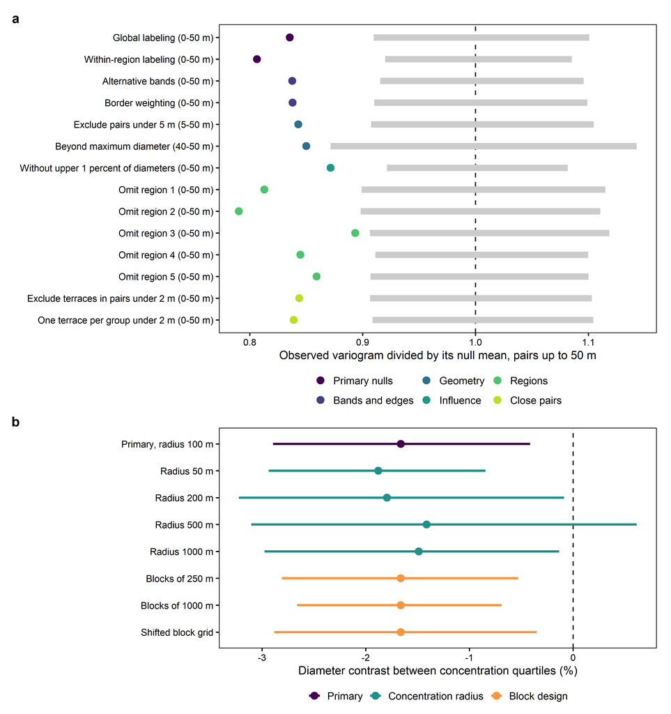

```r
# 44. Figure 8 plot
near_plot <- sens_near[sens_near$Supported, ]
near_plot$Label <- paste0(near_plot$Scenario, " (", fmt_num(near_plot$Distance_min_m), "-",
                          NEAR_MAX_M, " m)")
near_plot$Label <- factor(near_plot$Label, levels = rev(near_plot$Label))
p8a <- ggplot(near_plot, aes(Observed_ratio, Label)) +
  geom_vline(xintercept = 1, linetype = "dashed", colour = COL[["neutral"]], linewidth = 0.4) +
  geom_segment(aes(x = Null_low_ratio, xend = Null_high_ratio, yend = Label), colour = "grey80",
               linewidth = 2.2) +
  geom_point(aes(colour = Group), size = 2.3) +
  scale_colour_viridis_d(option = "viridis", end = 0.9, name = NULL, drop = FALSE) +
  guides(colour = guide_legend(nrow = 2)) +
  labs(x = "Observed variogram divided by its null mean, pairs up to 50 m", y = NULL) +
  theme_v7()
reg_plot <- sens_reg
reg_plot$Scenario <- factor(reg_plot$Scenario, levels = rev(reg_plot$Scenario))
p8b <- ggplot(reg_plot, aes(Effect, Scenario, colour = Group)) +
  geom_vline(xintercept = 0, linetype = "dashed", colour = COL[["neutral"]], linewidth = 0.4) +
  geom_segment(aes(x = Effect_low, xend = Effect_high, yend = Scenario), linewidth = 0.8) +
  geom_point(size = 2.3) +
  scale_colour_manual(values = c("Primary" = COL[["observed"]],
                                 "Concentration radius" = COL[["global"]],
                                 "Block design" = COL[["outside"]]),
                      breaks = c("Primary", "Concentration radius", "Block design"),
                      name = NULL) +
  labs(x = "Diameter contrast between concentration quartiles (%)", y = NULL) +
  theme_v7()
p8 <- (p8a / p8b) + plot_layout(heights = c(nrow(near_plot), nrow(reg_plot) + 2)) +
  plot_annotation(tag_levels = "a")
print(p8)
```

```r
SAVED_FIGURES <- c(SAVED_FIGURES, save_figure(p8, "FIGURE_8", FIG_HEIGHT_MM[["FIGURE_8"]]))
```

**Fig. 8** Robustness of short-range similarity. (a) Observed variogram divided by its null mean for pairs up to 50 m under alternative bands, edge weighting, geometric cutoffs, influence, regional omission and close-pair exclusions; grey bars are 95% null ranges. (b) Diameter contrast between concentration quartiles with 95% spatial block-bootstrap intervals

#### Figure 8. Numerical description

```r
# 46. Figure 8 report
report_start("Figure 8", "Robustness of short-range similarity and of the concentration contrast",
             paste("panel a observed over null-mean variogram for pairs up to 50 m with 95",
                   "percent null range, panel b concentration-quartile contrast with 95 percent",
                   "block-bootstrap interval"))
```

```
## REPORT=Figure 8
##     SHOWS=Robustness of short-range similarity and of the concentration contrast
## ENCODING=panel a observed over null-mean variogram for pairs up to 50 m with 95 percent
##     null range, panel b concentration-quartile contrast with 95 percent block-bootstrap
##     interval
```

```r
emit_rows(SCENARIO = sens_near$Scenario,
          DOMAIN_M = paste0(fmt_num(sens_near$Distance_min_m), "-", NEAR_MAX_M),
          N = sens_near$N, PAIRS = sens_near$Pairs, RATIO = fmt_num(sens_near$Observed_ratio, 3),
          NULL_95 = interval_text(sens_near$Null_low_ratio, sens_near$Null_high_ratio, 3),
          P = fmt_p(sens_near$P_scalar))
```

```
## SCENARIO=Global labeling; DOMAIN_M=0-50; N=2526; PAIRS=5355; RATIO=0.835
##     NULL_95=0.91 to 1.1; P=0.0002
## SCENARIO=Within-region labeling; DOMAIN_M=0-50; N=2526; PAIRS=5355; RATIO=0.806
##     NULL_95=0.92 to 1.09; P=0.0002
## SCENARIO=Alternative bands; DOMAIN_M=0-50; N=2526; PAIRS=5355; RATIO=0.838
##     NULL_95=0.916 to 1.1; P=0.002
## SCENARIO=Border weighting; DOMAIN_M=0-50; N=2526; PAIRS=5355; RATIO=0.838
##     NULL_95=0.91 to 1.1; P=0.002
## SCENARIO=Exclude pairs under 5 m; DOMAIN_M=5-50; N=2526; PAIRS=5216; RATIO=0.843
##     NULL_95=0.907 to 1.1; P=0.002
## SCENARIO=Beyond maximum diameter; DOMAIN_M=40-50; N=2526; PAIRS=1382; RATIO=0.85
##     NULL_95=0.872 to 1.14; P=0.02
## SCENARIO=Without upper 1 percent of diameters; DOMAIN_M=0-50; N=2500; PAIRS=5276
##     RATIO=0.872; NULL_95=0.922 to 1.08; P=0.002
## SCENARIO=Omit region 1; DOMAIN_M=0-50; N=1918; PAIRS=4168; RATIO=0.813
##     NULL_95=0.899 to 1.12; P=0.002
## SCENARIO=Omit region 2; DOMAIN_M=0-50; N=1945; PAIRS=4409; RATIO=0.79
##     NULL_95=0.898 to 1.11; P=0.002
## SCENARIO=Omit region 3; DOMAIN_M=0-50; N=2019; PAIRS=4252; RATIO=0.893
##     NULL_95=0.907 to 1.12; P=0.026
## SCENARIO=Omit region 4; DOMAIN_M=0-50; N=2122; PAIRS=4289; RATIO=0.845
##     NULL_95=0.911 to 1.1; P=0.002
## SCENARIO=Omit region 5; DOMAIN_M=0-50; N=2100; PAIRS=4299; RATIO=0.859
##     NULL_95=0.907 to 1.1; P=0.006
## SCENARIO=Exclude terraces in pairs under 2 m; DOMAIN_M=0-50; N=2475; PAIRS=5052
##     RATIO=0.844; NULL_95=0.907 to 1.1; P=0.002
## SCENARIO=One terrace per group under 2 m; DOMAIN_M=0-50; N=2498; PAIRS=5180; RATIO=0.839
##     NULL_95=0.909 to 1.1; P=0.002
```

```r
emit_rows(CONTRAST_SCENARIO = sens_reg$Scenario, EFFECT_PERCENT = fmt_num(sens_reg$Effect, 3),
          EFFECT_95 = interval_text(sens_reg$Effect_low, sens_reg$Effect_high, 3))
```

```
## CONTRAST_SCENARIO=Primary, radius 100 m; EFFECT_PERCENT=-1.66; EFFECT_95=-2.89 to -0.415
## CONTRAST_SCENARIO=Radius 50 m; EFFECT_PERCENT=-1.88; EFFECT_95=-2.94 to -0.845
## CONTRAST_SCENARIO=Radius 200 m; EFFECT_PERCENT=-1.8; EFFECT_95=-3.22 to -0.0868
## CONTRAST_SCENARIO=Radius 500 m; EFFECT_PERCENT=-1.41; EFFECT_95=-3.1 to 0.614
## CONTRAST_SCENARIO=Radius 1000 m; EFFECT_PERCENT=-1.49; EFFECT_95=-2.98 to -0.135
## CONTRAST_SCENARIO=Blocks of 250 m; EFFECT_PERCENT=-1.66; EFFECT_95=-2.81 to -0.528
## CONTRAST_SCENARIO=Blocks of 1000 m; EFFECT_PERCENT=-1.66; EFFECT_95=-2.66 to -0.689
## CONTRAST_SCENARIO=Shifted block grid; EFFECT_PERCENT=-1.66; EFFECT_95=-2.88 to -0.35
```

```r
below <- (sens_near$Supported & sens_near$Observed_ratio < sens_near$Null_low_ratio) %in% TRUE
emit_text("RESULT", paste0(sum(below), " of ", nrow(sens_near), " near-range scenarios fall below ",
                           "the 95 percent null range, with ratios from ",
                           interval_text(min(sens_near$Observed_ratio, na.rm = TRUE),
                                         max(sens_near$Observed_ratio, na.rm = TRUE), 3)))
```

```
## RESULT=14 of 14 near-range scenarios fall below the 95 percent null range, with ratios
##     from 0.79 to 0.893
```

```r
emit_rows(FIXED_DOMAIN_SCENARIO = sens_fixed$Scenario,
          RATIO_100_500_M = fmt_num(sens_fixed$Observed_ratio, 3),
          NULL_95 = interval_text(sens_fixed$Null_low_ratio, sens_fixed$Null_high_ratio, 3))
```

```
## FIXED_DOMAIN_SCENARIO=Global labeling; RATIO_100_500_M=1.06; NULL_95=0.938 to 1.06
## FIXED_DOMAIN_SCENARIO=Within-region labeling; RATIO_100_500_M=1.07
##     NULL_95=0.944 to 1.06
## FIXED_DOMAIN_SCENARIO=Alternative bands; RATIO_100_500_M=1.07; NULL_95=0.939 to 1.06
## FIXED_DOMAIN_SCENARIO=Border weighting; RATIO_100_500_M=1.01; NULL_95=0.931 to 1.08
## FIXED_DOMAIN_SCENARIO=Exclude pairs under 5 m; RATIO_100_500_M=1.06
##     NULL_95=0.936 to 1.06
## FIXED_DOMAIN_SCENARIO=Beyond maximum diameter; RATIO_100_500_M=1.06
##     NULL_95=0.939 to 1.07
## FIXED_DOMAIN_SCENARIO=Without upper 1 percent of diameters; RATIO_100_500_M=1.03
##     NULL_95=0.948 to 1.05
## FIXED_DOMAIN_SCENARIO=Omit region 1; RATIO_100_500_M=1.18; NULL_95=0.924 to 1.08
## FIXED_DOMAIN_SCENARIO=Omit region 2; RATIO_100_500_M=1.06; NULL_95=0.928 to 1.07
## FIXED_DOMAIN_SCENARIO=Omit region 3; RATIO_100_500_M=0.954; NULL_95=0.935 to 1.06
## FIXED_DOMAIN_SCENARIO=Omit region 4; RATIO_100_500_M=1.03; NULL_95=0.935 to 1.07
## FIXED_DOMAIN_SCENARIO=Omit region 5; RATIO_100_500_M=1.1; NULL_95=0.933 to 1.07
## FIXED_DOMAIN_SCENARIO=Exclude terraces in pairs under 2 m; RATIO_100_500_M=1.07
##     NULL_95=0.941 to 1.06
## FIXED_DOMAIN_SCENARIO=One terrace per group under 2 m; RATIO_100_500_M=1.07
##     NULL_95=0.942 to 1.07
```

```r
emit_text("NOTE", "Scenarios share the same inventory and are not independent tests")
```

```
## NOTE=Scenarios share the same inventory and are not independent tests
```

# 3. Manuscript tables

## Table 1. Inventory and dimensional variability

```r
# 48. Table1 build
table1 <- data.frame(
  Statistic = c("Terraces", "Survey area (km2)", "Terraces per km2", "Mean diameter (m)",
                "Standard deviation of diameter (m)", "Median diameter (m)",
                "Interquartile range (m)", "Range (m)", "Coefficient of variation (%)",
                "Terraces of 8 to 13 m (%)", "Gini coefficient of diameter",
                "Gini coefficient of circular-equivalent area",
                "Median nearest-neighbor distance (m)",
                "Median minimum circular-equivalent gap (m)",
                "Terraces with an overlapping circular equivalent"),
  Value = c(fmt_num(n), fmt_num(area_km2, 6), fmt_num(n / area_km2, 4),
            fmt_num(diam_summary$Mean, 4), fmt_num(diam_summary$SD, 3),
            fmt_num(diam_summary$Median), interval_text(diam_summary$Q1, diam_summary$Q3),
            interval_text(diam_summary$Min, diam_summary$Max), fmt_num(diam_summary$CV, 3),
            fmt_num(100 * diam_summary$Share_typical, 4), fmt_num(diam_summary$Gini_D, 3),
            fmt_num(diam_summary$Gini_area, 3), fmt_num(stats::median(nn_dist), 4),
            fmt_num(stats::median(min_gap), 3), fmt_num(sum(min_gap < 0))))
```

**Table 1** Inventory and dimensional variability of the 2,526 Tairona terraces. Circular-equivalent areas and gaps assume circular footprints

| Statistic | Value |
| --- | --- |
| Terraces | 2526 |
| Survey area (km2) | 52.1988 |
| Terraces per km2 | 48.39 |
| Mean diameter (m) | 10.65 |
| Standard deviation of diameter (m) | 2.95 |
| Median diameter (m) | 10 |
| Interquartile range (m) | 9 to 12 |
| Range (m) | 3 to 40 |
| Coefficient of variation (%) | 27.7 |
| Terraces of 8 to 13 m (%) | 91.05 |
| Gini coefficient of diameter | 0.129 |
| Gini coefficient of circular-equivalent area | 0.27 |
| Median nearest-neighbor distance (m) | 16.68 |
| Median minimum circular-equivalent gap (m) | 6.21 |
| Terraces with an overlapping circular equivalent | 688 |

## Table 2. Spatial dependence, effect sizes and model adequacy

```r
# 51. Table2 build
primary_p <- c(mark_global$curves$P_global[1], mark_regional$curves$P_global[1],
               slope_p[["Global"]], slope_p[["Regional"]], res_m1$near$P_global)
holm <- stats::p.adjust(primary_p, method = "holm")
t2 <- list()
add_row <- function(analysis, reference, estimate, range, p, draws) {
  t2[[length(t2) + 1L]] <<- data.frame(Analysis = analysis, Reference = reference,
                                       Estimate = estimate, Range = range, p = p, Draws = draws)
}
kernel_test <- if (is.null(pcf_calibrated)) pcf_main else pcf_calibrated
add_row("Pair correlation at 20 m",
        if (is.null(pcf_calibrated)) "Kernel intensity" else "Kernel intensity, calibrated",
        fmt_num(value_at(kernel_test, 20), 4), envelope_at(kernel_test, 20),
        fmt_p(kernel_test$P_global[1]),
        if (is.null(pcf_calibrated)) fmt_num(N_SIM) else paste(N_CAL_OUTER, "x", N_CAL_INNER))
if (!is.null(thomas_diag)) {
  add_row("Pair correlation at 20 m", paste("Thomas,", trend_label),
          fmt_num(value_at(thomas_diag, 20), 4), envelope_at(thomas_diag, 20),
          fmt_p(thomas_diag$P_global[1]), fmt_num(N_MODEL))
}
if (!is.null(thomas_fine)) {
  add_row("Fine-scale pair correlation at 5 m", paste("Thomas,", trend_label),
          fmt_num(value_at(thomas_fine, 5), 4), envelope_at(thomas_fine, 5),
          fmt_p(thomas_fine$P_global[1]), fmt_num(N_MODEL))
}
for (k in 1:2) {
  add_row("Variogram ratio, 0 to 50 m", sens_near$Scenario[k],
          fmt_num(sens_near$Observed_ratio[k], 3),
          interval_text(sens_near$Null_low_ratio[k], sens_near$Null_high_ratio[k], 3),
          paste0(fmt_p(primary_p[k]), " (Holm ", fmt_p(holm[k]), ")"), fmt_num(N_PERM))
}
for (k in 1:2) {
  add_row(paste0("Neighbor correlation, ", bt[k], " m"), "Global labeling",
          fmt_num(mark_global$rho$Observed[k], 3),
          interval_text(mark_global$rho$Low[k], mark_global$rho$High[k], 3),
          fmt_p(mark_global$decomposition$P_global[1]), fmt_num(N_PERM))
}
add_row("Concentration contrast, P25 to P75 (%)", "Spatial block bootstrap",
        fmt_num(boot_main$summary$Effect, 3),
        interval_text(boot_main$summary$Effect_low, boot_main$summary$Effect_high, 3),
        paste0(fmt_p(slope_p[["Global"]]), " (Holm ", fmt_p(holm[3]), ")"), fmt_num(N_BOOT))
add_row("Concentration contrast (SD of log diameter)", "Spatial block bootstrap",
        fmt_num(contrast$Standardized, 3),
        interval_text(contrast$Standardized_low, contrast$Standardized_high, 3), "",
        fmt_num(N_BOOT))
for (m in residual_models) {
  add_row("Residual variogram ratio, 0 to 50 m", m$near$Model, fmt_num(m$near$Ratio, 3),
          interval_text(m$near$Null_low, m$near$Null_high, 3),
          if (m$near$Model == "M1 concentration") {
            paste0(fmt_p(m$near$P_global), " (Holm ", fmt_p(holm[5]), ")")
          } else fmt_p(m$near$P_global), fmt_num(N_SIM))
}
add_row("Cross-validated MAE gain (mm)", "Concentration model",
        paste0(fmt_num(1000 * mean(cv_conc[, 3]), 3), " (", sum(cv_conc[, 3] > 0), " of ",
               CV_REPEATS, " positive)"),
        interval_text(1000 * min(cv_conc[, 3]), 1000 * max(cv_conc[, 3]), 3), "",
        fmt_num(CV_REPEATS))
table2 <- do.call(rbind, t2)
names(table2) <- c("Analysis", "Reference", "Estimate", "95% range", "p", "Draws")
```

**Table 2** Spatial dependence, effect sizes and model adequacy. Ranges are 95% global envelopes at the stated distance, 95% null ranges for ratios and correlations, or 95% spatial block-bootstrap intervals. Labeling and residual p values are global envelope tests over 0 to 2 km; the Holm adjustment covers the five primary tests

| Analysis | Reference | Estimate | 95% range | p | Draws |
| --- | --- | --- | --- | --- | --- |
| Pair correlation at 20 m | Kernel intensity, calibrated | 12.37 | 0.538 to 1.53 | 0.005 | 199 x 99 |
| Pair correlation at 20 m | Thomas, coordinate trend | 14.19 | 3.3 to 7.68 | 0.014 | 999 |
| Fine-scale pair correlation at 5 m | Thomas, coordinate trend | 20.87 | 3.26 to 7.6 | 0.002 | 999 |
| Variogram ratio, 0 to 50 m | Global labeling | 0.835 | 0.91 to 1.1 | 0.0004 (Holm 0.0016) | 10000 |
| Variogram ratio, 0 to 50 m | Within-region labeling | 0.806 | 0.92 to 1.09 | 0.0001 (Holm 0.0005) | 10000 |
| Neighbor correlation, 0-25 m | Global labeling | 0.0981 | -0.0422 to 0.0438 | 0.0001 | 10000 |
| Neighbor correlation, 25-50 m | Global labeling | 0.0889 | -0.0345 to 0.0337 | 0.0001 | 10000 |
| Concentration contrast, P25 to P75 (%) | Spatial block bootstrap | -1.66 | -2.89 to -0.415 | 0.0062 (Holm 0.019) | 10000 |
| Concentration contrast (SD of log diameter) | Spatial block bootstrap | -0.0685 | -0.12 to -0.017 |  | 10000 |
| Residual variogram ratio, 0 to 50 m | M1 concentration | 0.907 | 0.954 to 1.04 | 0.0098 (Holm 0.02) | 10000 |
| Residual variogram ratio, 0 to 50 m | M2 terrain | 0.905 | 0.956 to 1.04 | 0.017 | 10000 |
| Residual variogram ratio, 0 to 50 m | M3 concentration and terrain | 0.912 | 0.955 to 1.04 | 0.011 | 10000 |
| Cross-validated MAE gain (mm) | Concentration model | 0.865 (3 of 10 positive) | -2.27 to 8.67 |  | 10 |

#### Table 2. Numerical description

```r
# 53. Table2 report
report_start("Table 2", "Primary tests with Holm adjustment", "one line per primary test")
```

```
## REPORT=Table 2; SHOWS=Primary tests with Holm adjustment
## ENCODING=one line per primary test
```

```r
emit_rows(PRIMARY_TEST = c("Joint marks, global labeling", "Joint marks, within-region labeling",
                           "Concentration slope, global labeling",
                           "Concentration slope, within-region labeling",
                           "Residual variogram, M1 concentration"),
          P = fmt_p(primary_p), HOLM = fmt_p(holm))
```

```
## PRIMARY_TEST=Joint marks, global labeling; P=0.0004; HOLM=0.0016
## PRIMARY_TEST=Joint marks, within-region labeling; P=0.0001; HOLM=0.0005
## PRIMARY_TEST=Concentration slope, global labeling; P=0.0062; HOLM=0.019
## PRIMARY_TEST=Concentration slope, within-region labeling; P=0.018; HOLM=0.02
## PRIMARY_TEST=Residual variogram, M1 concentration; P=0.0098; HOLM=0.02
```

# 4. Audit and reproducibility

```r
# 55. Audit and reproducibility
SAVED_FIGURES <- unique(SAVED_FIGURES)
stopifnot(identical(D_ORIGINAL, D), nrow(terraces) == EXPECTED_TERRACES,
          length(SAVED_FIGURES) == 6L, all(file.exists(SAVED_FIGURES)),
          identical(basename(SAVED_FIGURES), paste0("FIGURE_", 3:8, ".pdf")),
          max(mark_global$identity_error, mark_regional$identity_error) < 1e-9,
          nrow(cv_conc) == CV_REPEATS, all(cv_conc[, 4] >= CV_BUFFER_M))
report_start("Audit", "Checks, inputs, computation and environment", "one line per item")
```

```
## REPORT=Audit; SHOWS=Checks, inputs, computation and environment
## ENCODING=one line per item
```

```r
emit_rows(FIGURE_FOLDER = FIG_DIR, FIGURE_FILES = paste(basename(SAVED_FIGURES), collapse = ", "))
```

```
## FIGURE_FOLDER=C:/Users/USER/OneDrive - University of Pittsburgh/ARTICULOS INGLES SIERRA
##     NEVADA DE SANTA MARTA/Anthropological and Archaeological Sciences/GITHUB/GITHUB
##     ONLINE
##     FIGURE_FILES=FIGURE_3.pdf, FIGURE_4.pdf, FIGURE_5.pdf, FIGURE_6.pdf, FIGURE_7.pdf,
##     FIGURE_8.pdf
```

```r
input_files <- c(terrace_path, polygon_path, dem_path)
emit_rows(GITHUB_REPOSITORY = paste(GITHUB_OWNER, GITHUB_REPO, sep = "/"),
          GITHUB_REF = GITHUB_REF, GITHUB_FOLDER = GITHUB_FOLDER)
```

```
## GITHUB_REPOSITORY=luismiguelsoto/Architectural_uniformity_and_spatial_variation_in_Tairo
## na_residential_terraces_of_the_Rio_Frio_basin
##     GITHUB_REF=main; GITHUB_FOLDER=Rdata
```

```r
emit_rows(INPUT = basename(input_files), MD5 = unname(tools::md5sum(input_files)))
```

```
## INPUT=AAS_TERRACES.RData; MD5=95cb948676512ee93989cd16a3374ce2
## INPUT=AAS_POLYGON_SURVEY_RIO_FRIO.RData; MD5=b360cbc7fe98167102a2823026a4dfb4
## INPUT=FINAL_DEM_GENERAL_ALOS_PALSAR.tif; MD5=867626df5997cfc0b18ee6298c78460c
```

```r
emit_rows(MONTE_CARLO_RUNS = nrow(MC_LOG), FROM_CACHE = sum(MC_LOG$Cached),
          COMPUTED = sum(!MC_LOG$Cached), MONTE_CARLO_SECONDS = sum(MC_LOG$Seconds),
          SLOWEST_RUN = MC_LOG$Label[which.max(MC_LOG$Seconds)],
          SLOWEST_SECONDS = max(MC_LOG$Seconds))
```

```
## MONTE_CARLO_RUNS=47; FROM_CACHE=0; COMPUTED=47; MONTE_CARLO_SECONDS=3302
##     SLOWEST_RUN=Broad PCF, nested calibration; SLOWEST_SECONDS=997.7
```

```r
emit_rows(CACHE = USE_CACHE, CACHE_DIR = CACHE_DIR)
```

```
## CACHE=TRUE; CACHE_DIR=C:\Users\USER\AppData\Local/R/cache/R/riofrio_terraces
```

```r
emit_rows(SEED = SEED, R = R.version.string, PLATFORM = R.version$platform,
          OS = Sys.info()[["sysname"]], WORKERS = CPU_WORKERS)
```

```
## SEED=20261110; R=R version 4.6.1 (2026-06-24 ucrt); PLATFORM=x86_64-w64-mingw32
##     OS=Windows; WORKERS=30
```

```r
emit_rows(PACKAGES = paste(vapply(req, function(p)
  paste0(p, " ", as.character(utils::packageVersion(p))), character(1)), collapse = ", "))
```

```
## PACKAGES=sf 1.1.3, ggplot2 4.0.3, patchwork 1.3.2, scales 1.4.0, knitr 1.52,
##     spatstat.geom 3.8.2, spatstat.explore 3.8.2, spatstat.random 3.5.1, spatstat.model
##     3.7.2, GET 1.0.9, curl 8.0.0, terra 1.9.50
```

```r
emit_rows(MAP_PACKAGE = paste0("ggspatial ", as.character(utils::packageVersion("ggspatial"))))
```

```
## MAP_PACKAGE=ggspatial 1.1.11
```

```r
emit_rows(QUICK_TEST = QUICK_TEST, RESULTS_FOR_INFERENCE = !QUICK_TEST,
          TERRAIN_MARKS = USE_DEM_MARKS, TERRAIN_INTENSITY = USE_DEM_INTENSITY,
          ELAPSED_SECONDS = round(as.numeric(difftime(Sys.time(), RUN_STARTED_AT,
                                                      units = "secs")), 1))
```

```
## QUICK_TEST=FALSE; RESULTS_FOR_INFERENCE=TRUE; TERRAIN_MARKS=TRUE
##     TERRAIN_INTENSITY=FALSE; ELAPSED_SECONDS=3400
```

```r
if (!is.null(CLUSTER)) {
  parallel::stopCluster(CLUSTER)
  CLUSTER <- NULL
}
```